# Gene–Metabolite Pathway Analysis

Sneha M. Chaturvedi

Last updated 2026-09-10

Metabolite set enrichment (MSEA/ORA) on the metabolite-side results from gene-metabolite associations. Tests whether metabolites associated with specific cell types are enriched in KEGG/Reactome/WikiPathways.

[output not shown]

## Overview

Pathway analysis (ORA + MSEA) on imputation-stable gene–metabolite associations. Hits are pre-filtered to global FDR < 0.10 and |logFC| ≥ 0.25

Three analyses:

1. **All cell types (union)** — metabolites significant in ≥1 cell type
2. **Cell-type-specific** — ORA + MSEA run independently per cell type
3. **Glia vs. neurons** — metabolites associating primarily with glial or neuronal cell types, plus their exclusive pathway enrichments and shared pathway comparison

**ORA**: Fisher’s exact test; foreground = metabolites with ≥1 significant gene association (within FDR < 0.10, |logFC| ≥ 0.25); background = all measured metabolites.

**MSEA**: fgsea ranked by −log10(min raw *P*-value per metabolite) computed from the full parquet archive. This ranking is unsigned — it captures association strength without imposing a direction, since one metabolite can drive many gene associations with mixed signs.

## Set Up

```r
Packages <- c(
  "readxl", "tidyverse", "arrow", "fgsea",
  "KEGGREST", "knitr", "kableExtra", "svglite", "ggrepel", "cowplot"
)
lapply(Packages, library, character.only = TRUE)
```

[output not shown]

```r
find_project_root <- function(marker = ".git") {
  d <- normalizePath(getwd())
  repeat {
    if (dir.exists(file.path(d, marker))) return(d)
    parent <- dirname(d)
    if (parent == d) stop("Project root not found (no ", marker, " above ", getwd(), ")")
    d <- parent
  }
}
root <- find_project_root()
source(file.path(root, "src/gene-hormone/pseudobulk_functions.R"))   # save_dual_format()

set.seed(42)

find_project_root <- function(marker = ".git") {
  d <- normalizePath(getwd())
  repeat {
    if (dir.exists(file.path(d, marker))) return(d)
    parent <- dirname(d)
    if (parent == d) stop("Could not locate project root (no ", marker, " found above ", getwd(), ")")
    d <- parent
  }
}
results_dir <- file.path(find_project_root(), "results")
```

```r
# ---- METHOD must match metabolite_gene_imputation_sensitivity.Rmd -----------
METHOD <- "log2_na"
suffix <- if (METHOD == "int") "" else paste0("-", METHOD)

# ---- paths -------------------------------------------------------------------
parquet_dir <- if (METHOD == "int") {
  file.path(results_dir, "gene-metabolite/parquet")
} else {
  file.path(results_dir, sprintf("gene-metabolite/parquet-%s", METHOD))
}

iter_dir  <- file.path(results_dir, "gene-metabolite",
                       paste0("stability-imputation", suffix))
hits_path <- file.path(iter_dir, "metabolite_gene_hits_imputation_stable.csv")
annot_path <- file.path(results_dir, "untargeted/metabolite_annotations_flagged.csv")

out_dir  <- file.path(iter_dir, "pathway")
csv_path <- file.path(out_dir, "csv")
for (d in c(out_dir, csv_path)) dir.create(d, recursive = TRUE, showWarnings = FALSE)

# ---- thresholds (must match metabolite_gene_imputation_sensitivity.Rmd) -----
FDR_GLOBAL  <- 0.10   # global BH threshold applied upstream
LFC_MIN     <- 0.25   # applied upstream
MIN_CT_HITS <- 5      # min distinct metabolite hits to run ORA for a cell type

# ---- cell type groupings -----------------------------------------------------
# UPDATE these after inspecting the "Available Cell Types" section below.
# Use exact strings from unique(hits$cell_type).
GLIAL_TYPES <- c(
  "Astrocyte-Immature", "OPC"
)
NEURONAL_TYPES <- c(
  "EN-IT-Immature", "EN-L6-IT", "EN-L6b", "EN-Newborn", "EN-Non-IT-Immature",
  "IN-CGE-Immature", "IN-MGE-Immature", "IN-MGE-SST", "IPC-EN"
)
```

## Load Hits

```r
hits <- read_csv(hits_path, show_col_types = FALSE)

cat(sprintf("Reading: %s\n", hits_path))
```

```
## Reading: /scratch/jdlab/sneha/developing-brain-metabolomics/results/gene-metabolite/stability-imputation-log2_na/metabolite_gene_hits_imputation_stable.csv
```

```r
cat(sprintf(
  "Imputation-stable hits: %s rows | %d metabolites | %d cell types | %d genes\n",
  format(nrow(hits), big.mark = ","),
  n_distinct(hits$Compound.ID),
  n_distinct(hits$cell_type),
  n_distinct(hits$gene)
))
```

```
## Imputation-stable hits: 1,105 rows | 221 metabolites | 11 cell types | 538 genes
```

## Available Cell Types

Inspect this output to set `GLIAL_TYPES` and `NEURONAL_TYPES` in the config chunk.

```r
cat("Cell types present in hits:\n")
```

```
## Cell types present in hits:
```

```r
print(sort(unique(hits$cell_type)))
```

```
##  [1] "Astrocyte-Immature" "EN-IT-Immature"     "EN-L6-IT"
##  [4] "EN-L6b"             "EN-Newborn"         "EN-Non-IT-Immature"
##  [7] "IN-CGE-Immature"    "IN-MGE-Immature"    "IN-MGE-SST"
## [10] "IPC-EN"             "OPC"
```

## MSEA Rankings (Parquet)

For each metabolite compute min raw *P*-value across all gene × cell type pairs.

```r
ds <- open_dataset(parquet_dir)

# All-cell-types ranking
ranking_all_raw <- ds |>
  group_by(Compound.ID, Name) |>
  summarise(min_P = min(P.Value, na.rm = TRUE), .groups = "drop") |>
  collect()

# Cell-type-specific rankings (used in loop and glia/neuron analyses)
ranking_ct_raw <- ds |>
  group_by(cell_type, Compound.ID, Name) |>
  summarise(min_P = min(P.Value, na.rm = TRUE), .groups = "drop") |>
  collect()

cat(sprintf(
  "All-metabolite ranking rows:  %d\n",
  nrow(ranking_all_raw)
))
```

```
## All-metabolite ranking rows:  513
```

```r
cat(sprintf(
  "Cell-type ranking rows: %s\n",
  format(nrow(ranking_ct_raw), big.mark = ",")
))
```

```
## Cell-type ranking rows: 4,592
```

# Pathway Annotation

Background = all metabolites that entered the gene–metabolite loop.

## Load Annotation

```r
batch2_compound_annotation_full <- read_csv(
  file.path(root, "results/untargeted/metabolite_annotations_flagged.csv"),
  show_col_types = FALSE
)

# Background = every metabolite present in the parquet archive
background_all <- ranking_all_raw$Name

batch2_compound_annotation <- batch2_compound_annotation_full |>
  filter(Name %in% background_all)

pathway_info <- read_excel(
  file.path(root, "doc/untargeted/combined_annotations_untargeted_developing_2026.xlsx"),
  sheet = "Pathways"
) |>
  rename(
    pathway_id     = PathwayId,
    pathway_name   = pathwayName,
    pathway_source = pathwaySource
  ) |>
  dplyr::select(pathway_id, pathway_name, pathway_source)

cat(sprintf(
  "Background metabolites: %d | annotation rows: %d\n",
  length(background_all), nrow(batch2_compound_annotation)
))
```

```
## Background metabolites: 513 | annotation rows: 513
```

## Parse Existing Pathways

```r
pathways_parsed <- batch2_compound_annotation |>
  filter(!is.na(Pathways) & Pathways != "") |>
  dplyr::select(Compound.ID, Name, KEGG, Pathways) |>
  separate_rows(Pathways, sep = ";") |>
  mutate(
    pathway_id = str_trim(Pathways),
    pathway_source = case_when(
      str_detect(pathway_id, "^map\\d+") ~ "kegg",
      str_detect(pathway_id, "^R-HSA-")  ~ "reactome",
      str_detect(pathway_id, "^WP\\d+$") ~ "wiki",
      TRUE                               ~ NA_character_
    )
  ) |>
  dplyr::select(-Pathways) |>
  filter(!is.na(pathway_id) & pathway_id != "" & !is.na(pathway_source))

cat(sprintf(
  "Metabolites with existing pathway annotation: %d of %d\n",
  n_distinct(pathways_parsed$Name), nrow(batch2_compound_annotation)
))
```

```
## Metabolites with existing pathway annotation: 179 of 513
```

```r
cat("Breakdown by source:\n")
```

```
## Breakdown by source:
```

```r
print(count(pathways_parsed, pathway_source))
```

```
## # A tibble: 3 × 2
##   pathway_source     n
##   <chr>          <int>
## 1 kegg             279
## 2 reactome        2754
## 3 wiki            1098
```

## KEGGREST Re-Mapping

```r
metabolites_missing_pathways <- batch2_compound_annotation |>
  filter(is.na(Pathways) | Pathways == "") |>
  filter(!is.na(KEGG) & KEGG != "") |>
  dplyr::select(Compound.ID, Name, KEGG) |>
  separate_rows(KEGG, sep = ";") |>
  mutate(
    KEGG       = str_trim(KEGG),
    KEGG_valid = str_detect(KEGG, "^C\\d{5}$")
  ) |>
  filter(!is.na(KEGG) & KEGG != "")

valid_ids <- metabolites_missing_pathways |>
  filter(KEGG_valid) |>
  pull(KEGG) |>
  unique()

cat(sprintf(
  "Missing annotation: %d metabolites | KEGG IDs to query: %d\n",
  n_distinct(metabolites_missing_pathways |> filter(KEGG_valid) |> pull(Name)),
  length(valid_ids)
))
```

```
## Missing annotation: 33 metabolites | KEGG IDs to query: 35
```

```r
query_kegg_pathways <- function(kegg_ids) {
  results <- vector("list", length(kegg_ids))
  for (i in seq_along(kegg_ids)) {
    kid <- kegg_ids[i]
    results[[i]] <- tryCatch({
      links <- keggLink("pathway", paste0("cpd:", kid))
      tibble(KEGG = kid, pathway_id = str_remove(links, "path:"))
    }, error = function(e) {
      message("  Query failed for ", kid, ": ", e$message)
      tibble(KEGG = character(), pathway_id = character())
    })
    if (i %% 10 == 0) { cat("  ", i, "/", length(kegg_ids), "\n"); flush.console() }
    Sys.sleep(0.35)
  }
  bind_rows(results)
}

kegg_link_df <- query_kegg_pathways(valid_ids)
```

```
##    10 / 35
##    20 / 35
##    30 / 35
```

```r
if (nrow(kegg_link_df) > 0) {
  kegg_new <- metabolites_missing_pathways |>
    inner_join(kegg_link_df, by = "KEGG") |>
    mutate(pathway_source = "kegg") |>
    dplyr::select(Compound.ID, Name, KEGG, pathway_source, pathway_id)
  cat(sprintf(
    "New KEGG assignments: %d rows | %d metabolites\n",
    nrow(kegg_new), n_distinct(kegg_new$Name)
  ))
} else {
  kegg_new <- tibble(
    Compound.ID = character(), Name = character(), KEGG = character(),
    pathway_source = character(), pathway_id = character()
  )
  cat("No KEGG pathway links returned.\n")
}
```

```
## New KEGG assignments: 64 rows | 18 metabolites
```

## Combine and Map Pathway Names

```r
pathways_combined <- bind_rows(
  pathways_parsed,
  kegg_new |> dplyr::select(Compound.ID, Name, pathway_source, pathway_id)
) |>
  left_join(
    pathway_info |> dplyr::select(pathway_id, pathway_name),
    by = "pathway_id"
  ) |>
  mutate(
    pathway_label = case_when(
      !is.na(pathway_name) & pathway_name != "" ~ pathway_name,
      pathway_source == "kegg"     ~ paste0("KEGG:",         pathway_id),
      pathway_source == "reactome" ~ paste0("Reactome:",     pathway_id),
      pathway_source == "wiki"     ~ paste0("WikiPathways:", pathway_id),
      TRUE                         ~ pathway_id
    )
  )

cat(sprintf(
  "Final coverage: %d metabolites with pathway annotation | %d unique pathways\n",
  n_distinct(pathways_combined$Name),
  n_distinct(pathways_combined$pathway_id)
))
```

```
## Final coverage: 197 metabolites with pathway annotation | 1738 unique pathways
```

## Build Pathway Sets

```r
pathway_sets_raw <- pathways_combined |>
  distinct(Name, pathway_id, pathway_label, pathway_source) |>
  filter(Name %in% background_all)

pathway_sets <- pathway_sets_raw |>
  mutate(pathway_source = factor(
    pathway_source,
    levels = c("kegg",  "reactome", "wiki",          "pfocr"),
    labels = c("KEGG",  "Reactome", "WikiPathways",  "PFOCR")
  )) |>
  group_by(pathway_label, pathway_source) |>
  summarise(members = list(unique(Name)), .groups = "drop") |>
  mutate(
    n_members         = lengths(members),
    pathway_label_src = paste0(pathway_label, " (", pathway_source, ")")
  ) |>
  filter(n_members >= 5, n_members <= 500)

pathway_source_lookup <- pathway_sets |>
  dplyr::select(pathway_label_src, pathway_source)

pathway_list <- setNames(pathway_sets$members, pathway_sets$pathway_label_src)

cat(sprintf(
  "Pathway sets: %d | median members: %d | range: %d–%d\n",
  length(pathway_list), median(lengths(pathway_list)),
  min(lengths(pathway_list)), max(lengths(pathway_list))
))
```

```
## Pathway sets: 194 | median members: 7 | range: 5–25
```

# Analysis Functions

```r
# ---- ORA (Fisher's exact, one-sided greater) ---------------------------------
run_ora <- function(foreground, background, pathway_list,
                    pathway_source_lookup, analysis_label) {
  cat("\n===", analysis_label, "===\n")
  cat("Foreground:", length(foreground), "| Background:", length(background), "\n")

  if (length(foreground) < 1) { cat("Empty foreground — skipping.\n"); return(NULL) }

  bg_only <- background[!background %in% foreground]

  results <- map_dfr(names(pathway_list), function(pw) {
    members <- pathway_list[[pw]]
    a <- sum(foreground %in% members)
    b <- length(foreground) - a
    c <- sum(bg_only %in% members)
    d <- length(bg_only) - c
    ft <- fisher.test(matrix(c(a, b, c, d), nrow = 2), alternative = "greater")
    tibble(
      pathway    = pw,
      n_hits     = a,
      set_size   = a + c,
      odds_ratio = as.numeric(ft$estimate),
      pval       = ft$p.value,
      hit_names  = paste(foreground[foreground %in% members], collapse = ";")
    )
  }) |>
    filter(n_hits > 0) |>
    mutate(padj = p.adjust(pval, method = "BH")) |>
    left_join(pathway_source_lookup, by = c("pathway" = "pathway_label_src")) |>
    arrange(padj, pval)

  cat("Pathways with \u22651 hit:", nrow(results),
      "| p < 0.05:", sum(results$pval < 0.05, na.rm = TRUE),
      "| FDR < 0.05:", sum(results$padj < 0.05, na.rm = TRUE), "\n")
  results
}

# ---- MSEA (fgsea on −log10 min P per metabolite) ----------------------------
# ranking_df : data frame with columns Name, min_P (from parquet group_by)
# background_names : all measured metabolite Names; those absent from ranking_df
#                    are assigned score = 0 (i.e. min_P = 1)
run_msea_metab <- function(ranking_df, background_names, pathway_list,
                           analysis_label, nperm = 10000, seed = 42) {
  cat("\n===", analysis_label, "===\n")

  ranked <- tibble(Name = background_names) |>
    left_join(ranking_df |> dplyr::select(Name, min_P), by = "Name") |>
    mutate(score = -log10(pmax(replace_na(min_P, 1), 1e-300))) |>
    arrange(desc(score)) |>
    dplyr::select(Name, score) |>
    deframe()

  cat("Metabolites in ranked list:", length(ranked), "\n")

  pathway_list_filt <- lapply(pathway_list, function(x) intersect(x, names(ranked)))
  pathway_list_filt <- pathway_list_filt[lengths(pathway_list_filt) >= 5]
  cat("Pathway sets after intersection:", length(pathway_list_filt), "\n")

  if (length(pathway_list_filt) == 0) {
    cat("No pathway sets with sufficient coverage — skipping.\n")
    return(NULL)
  }

  set.seed(seed)
  results <- fgsea(
    pathways    = pathway_list_filt,
    stats       = ranked,
    nPermSimple = nperm,
    minSize     = 5,
    maxSize     = 500,
    scoreType   = "pos"
  ) |>
    as_tibble() |>
    arrange(padj, pval) |>
    mutate(analysis = analysis_label)

  cat("Pathways tested:", nrow(results),
      "| p < 0.05:", sum(results$pval < 0.05, na.rm = TRUE),
      "| FDR < 0.05:", sum(results$padj < 0.05, na.rm = TRUE), "\n")
  results
}

# ---- Plots -------------------------------------------------------------------
plot_ora_dotplot <- function(results, analysis_label, top_n = 20) {
  if (is.null(results) || nrow(results) == 0) return(NULL)

  plot_data <- results |>
    filter(pval < 0.05) |>
    head(top_n) |>
    mutate(
      stars = case_when(padj < 0.01 ~ "**", padj < 0.05 ~ "*", TRUE ~ ""),
      pathway_base  = str_remove(pathway,
        " \\(KEGG\\)$| \\(Reactome\\)$| \\(WikiPathways\\)$| \\(PFOCR\\)$"),
      pathway_short = str_trunc(pathway_base, 45),
      pathway_label = paste0(pathway_short, " (", pathway_source, ")",
                             if_else(stars != "", paste0(" ", stars), ""))
    )

  if (nrow(plot_data) == 0) { message("No nominal hits for: ", analysis_label); return(NULL) }

  ggplot(plot_data,
         aes(x = log2(odds_ratio),
             y = reorder(pathway_label, log2(odds_ratio)),
             color = pathway_source, shape = pathway_source, size = set_size)) +
    geom_point(alpha = 0.85) +
    geom_vline(xintercept = 0, linetype = "dashed", color = "grey50") +
    scale_color_manual(name = "Database",
      values = c(KEGG = "#E41A1C", Reactome = "#377EB8",
                 WikiPathways = "#4DAF4A", PFOCR = "#FF7F00")) +
    scale_shape_manual(name = "Database",
      values = c(KEGG = 16, Reactome = 17, WikiPathways = 15, PFOCR = 18)) +
    scale_size_continuous(name = "Set size", range = c(2, 8)) +
    theme_minimal(base_size = 11) +
    labs(x = "log2(Odds Ratio)", y = NULL,
         title    = paste0("ORA \u2014 ", analysis_label),
         subtitle = paste0("Top ", nrow(plot_data), " by p-value (p < 0.05 shown)\n",
                           "* FDR < 0.05   ** FDR < 0.01")) +
    theme(plot.title    = element_text(hjust = 0.5),
          plot.subtitle = element_text(hjust = 0.5, color = "grey40", size = 9),
          axis.text.y   = element_text(size = 8),
          legend.position = "right")
}

plot_msea_dotplot <- function(results, pathway_source_lookup, analysis_label, top_n = 25) {
  if (is.null(results) || nrow(results) == 0) return(NULL)

  plot_data <- results |>
    left_join(pathway_source_lookup, by = c("pathway" = "pathway_label_src")) |>
    filter(pval < 0.05) |>
    arrange(padj) |>
    head(top_n) |>
    mutate(
      stars = case_when(padj < 0.01 ~ "**", padj < 0.05 ~ "*", TRUE ~ ""),
      pathway_base  = str_remove(pathway,
        " \\(KEGG\\)$| \\(Reactome\\)$| \\(WikiPathways\\)$| \\(PFOCR\\)$"),
      pathway_short = str_trunc(pathway_base, 45),
      pathway_label = paste0(pathway_short, " (", pathway_source, ")",
                             if_else(stars != "", paste0(" ", stars), ""))
    )

  if (nrow(plot_data) == 0) { message("No nominal hits for: ", analysis_label); return(NULL) }

  ggplot(plot_data,
         aes(x = NES,
             y = reorder(pathway_label, NES),
             color = pathway_source, shape = pathway_source, size = size)) +
    geom_point(alpha = 0.85) +
    geom_vline(xintercept = 0, linetype = "dashed", color = "grey50") +
    scale_color_manual(name = "Database",
      values = c(KEGG = "#E41A1C", Reactome = "#377EB8",
                 WikiPathways = "#4DAF4A", PFOCR = "#FF7F00")) +
    scale_shape_manual(name = "Database",
      values = c(KEGG = 16, Reactome = 17, WikiPathways = 15, PFOCR = 18)) +
    scale_size_continuous(name = "Set size", range = c(2, 8)) +
    theme_minimal(base_size = 11) +
    labs(x = "Normalized Enrichment Score (NES)", y = NULL,
         title    = paste0("MSEA \u2014 ", analysis_label),
         subtitle = paste0("Top ", nrow(plot_data), " by FDR (p < 0.05 shown)\n",
                           "* FDR < 0.05   ** FDR < 0.01")) +
    theme(plot.title    = element_text(hjust = 0.5),
          plot.subtitle = element_text(hjust = 0.5, color = "grey40", size = 9),
          axis.text.y   = element_text(size = 8),
          legend.position = "right")
}

# ---- Table helper ------------------------------------------------------------
display_results_table <- function(results, caption, top_n = 20,
                                  type = c("ora", "msea")) {
  type <- match.arg(type)
  if (is.null(results) || nrow(results) == 0) { cat("No results.\n"); return(invisible(NULL)) }

  if (type == "ora") {
    results |>
      head(top_n) |>
      mutate(odds_ratio = round(odds_ratio, 2),
             pval = signif(pval, 3), padj = signif(padj, 3),
             hit_names = str_trunc(hit_names, 60)) |>
      dplyr::select(pathway, pathway_source, n_hits, set_size,
                    odds_ratio, pval, padj, hit_names) |>
      rename(Pathway = pathway, Source = pathway_source,
             Hits = n_hits, `Set size` = set_size,
             OR = odds_ratio, `p-value` = pval, FDR = padj,
             `Hit metabolites` = hit_names) |>
      kable(caption = caption) |>
      kable_styling(bootstrap_options = c("striped", "condensed"),
                    full_width = FALSE, font_size = 11) |>
      print()
  } else {
    results |>
      left_join(pathway_source_lookup, by = c("pathway" = "pathway_label_src")) |>
      head(top_n) |>
      mutate(pval = signif(pval, 3), padj = signif(padj, 3),
             NES  = round(NES, 3),
             leadingEdge = map_chr(leadingEdge, ~ paste(head(.x, 5), collapse = ", "))) |>
      dplyr::select(pathway, pathway_source, pval, padj, NES, size, leadingEdge) |>
      rename(Pathway = pathway, Source = pathway_source,
             `p-value` = pval, FDR = padj, NES = NES,
             `Set size` = size, `Leading edge (top 5)` = leadingEdge) |>
      kable(caption = caption) |>
      kable_styling(bootstrap_options = c("striped", "condensed"),
                    full_width = FALSE, font_size = 11) |>
      print()
  }
}

# flatten leadingEdge list column before write_csv
flatten_leading_edge <- function(df) {
  if (!is.null(df) && "leadingEdge" %in% colnames(df))
    df |> mutate(leadingEdge = map_chr(leadingEdge, ~ paste(.x, collapse = ";")))
  else df
}
```

# 1. All Cell Types (Union)

Foreground: distinct metabolites significant in ≥1 cell type.

## ORA and MSEA

```r
hits_all <- hits |> distinct(Name) |> pull(Name)
cat("Union metabolite hits:", length(hits_all), "\n")
```

```
## Union metabolite hits: 221
```

```r
ora_all  <- run_ora(
  hits_all, background_all, pathway_list,
  pathway_source_lookup, "All cell types (union)"
)
```

```
##
## === All cell types (union) ===
## Foreground: 221 | Background: 513
## Pathways with ≥1 hit: 193 | p < 0.05: 13 | FDR < 0.05: 0
```

```r
msea_all <- run_msea_metab(
  ranking_all_raw, background_all, pathway_list,
  "All cell types"
)
```

```
##
## === All cell types ===
## Metabolites in ranked list: 513
## Pathway sets after intersection: 194
## Pathways tested: 194 | p < 0.05: 21 | FDR < 0.05: 0
```

## ORA — Table and Plot

```r
display_results_table(ora_all, "ORA: All cell types — top 20 by FDR", type = "ora")
```

[output not shown]

[output cut: 162 more lines]

[output not shown]

```
## Saved: ora_all_celltypes.png  +  svg/ora_all_celltypes.svg
```

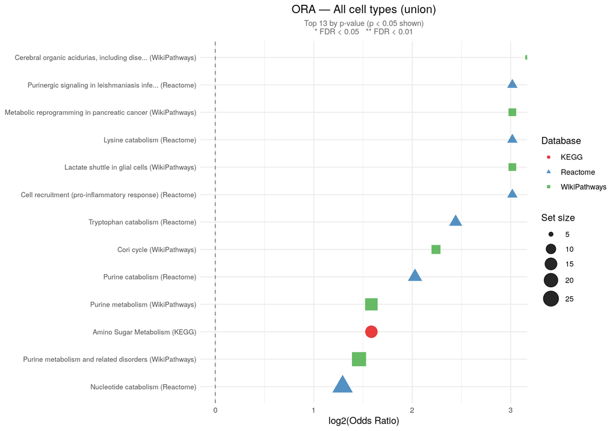

```r
p <- plot_ora_dotplot(ora_all, "All cell types (union)")
if (!is.null(p)) {
  save_dual_format(p, out_dir, "ora_all_celltypes")
  print(p)
}
```

## MSEA — Table and Plot

```r
display_results_table(msea_all, "MSEA: All cell types — top 20 by FDR", type = "msea")
```

[output not shown]

[output cut: 141 more lines]

[output not shown]

```
## Saved: msea_all_celltypes.png  +  svg/msea_all_celltypes.svg
```

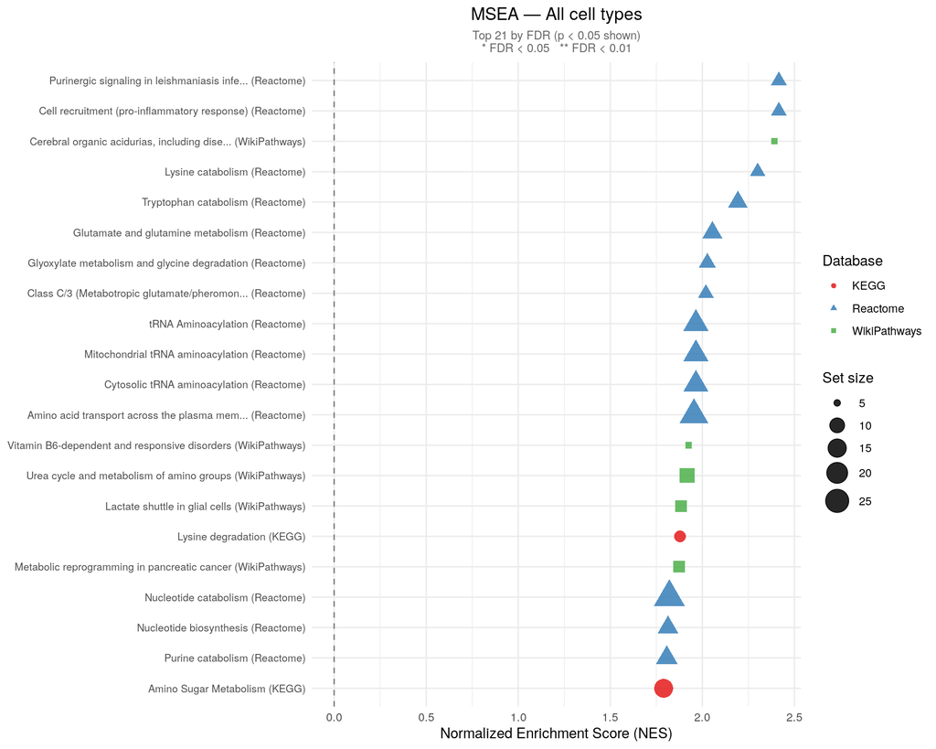

```r
p <- plot_msea_dotplot(msea_all, pathway_source_lookup, "All cell types")
if (!is.null(p)) {
  save_dual_format(p, out_dir, "msea_all_celltypes")
  print(p)
}
```

# 2. Cell-Type-Specific

ORA and MSEA run per cell type. Cell types with fewer than 5 metabolite hits are skipped for ORA.

```r
cell_types    <- sort(unique(hits$cell_type))
ora_ct_list   <- list()
msea_ct_list  <- list()

for (ct in cell_types) {
  ct_hits <- hits |> filter(cell_type == ct) |> distinct(Name) |> pull(Name)
  cat(sprintf("\n--- %s | %d metabolite hits ---\n", ct, length(ct_hits)))

  if (length(ct_hits) >= MIN_CT_HITS) {
    ora_ct_list[[ct]] <- run_ora(
      ct_hits, background_all, pathway_list, pathway_source_lookup, ct
    )
  } else {
    cat("  ORA skipped: fewer than", MIN_CT_HITS, "hits\n")
  }

  ct_ranking <- ranking_ct_raw |> filter(cell_type == ct)
  if (nrow(ct_ranking) > 0) {
    msea_ct_list[[ct]] <- run_msea_metab(
      ct_ranking, background_all, pathway_list, ct
    )
  }
}
```

```
##
## --- Astrocyte-Immature | 27 metabolite hits ---
##
## === Astrocyte-Immature ===
## Foreground: 27 | Background: 513
## Pathways with ≥1 hit: 119 | p < 0.05: 10 | FDR < 0.05: 0
##
## === Astrocyte-Immature ===
## Metabolites in ranked list: 513
## Pathway sets after intersection: 194
## Pathways tested: 194 | p < 0.05: 25 | FDR < 0.05: 0
##
## --- EN-IT-Immature | 18 metabolite hits ---
##
## === EN-IT-Immature ===
## Foreground: 18 | Background: 513
## Pathways with ≥1 hit: 117 | p < 0.05: 22 | FDR < 0.05: 0
##
## === EN-IT-Immature ===
## Metabolites in ranked list: 513
## Pathway sets after intersection: 194
## Pathways tested: 194 | p < 0.05: 3 | FDR < 0.05: 0
##
## --- EN-L6-IT | 19 metabolite hits ---
##
## === EN-L6-IT ===
## Foreground: 19 | Background: 513
## Pathways with ≥1 hit: 43 | p < 0.05: 0 | FDR < 0.05: 0
##
## === EN-L6-IT ===
## Metabolites in ranked list: 513
## Pathway sets after intersection: 194
## Pathways tested: 194 | p < 0.05: 14 | FDR < 0.05: 0
##
## --- EN-L6b | 27 metabolite hits ---
##
## === EN-L6b ===
## Foreground: 27 | Background: 513
## Pathways with ≥1 hit: 58 | p < 0.05: 3 | FDR < 0.05: 0
##
```

[output cut: 63 more lines]

```
## === IPC-EN ===
## Metabolites in ranked list: 513
## Pathway sets after intersection: 194
## Pathways tested: 194 | p < 0.05: 22 | FDR < 0.05: 6
##
## --- OPC | 68 metabolite hits ---
##
## === OPC ===
## Foreground: 68 | Background: 513
## Pathways with ≥1 hit: 107 | p < 0.05: 9 | FDR < 0.05: 0
##
## === OPC ===
## Metabolites in ranked list: 513
## Pathway sets after intersection: 194
## Pathways tested: 194 | p < 0.05: 13 | FDR < 0.05: 0
```

```r
cat(sprintf(
  "\nCompleted: ORA for %d cell types | MSEA for %d cell types\n",
  length(ora_ct_list), length(msea_ct_list)
))
```

```
##
## Completed: ORA for 10 cell types | MSEA for 11 cell types
```

## Cell-Type ORA — Summary Table

Top 3 pathways per cell type (p < 0.05).

```r
ct_ora_summary <- map_dfr(names(ora_ct_list), function(ct) {
  res <- ora_ct_list[[ct]]
  if (is.null(res) || nrow(res) == 0) return(NULL)
  res |>
    filter(pval < 0.05) |>
    slice_head(n = 3) |>
    mutate(
      cell_type     = ct,
      pathway_short = str_trunc(str_remove(
        pathway, " \\(KEGG\\)$| \\(Reactome\\)$| \\(WikiPathways\\)$| \\(PFOCR\\)$"
      ), 40)
    )
})

if (nrow(ct_ora_summary) > 0) {
  ct_ora_summary |>
    dplyr::select(cell_type, pathway_short, pathway_source,
                  n_hits, set_size, odds_ratio, pval, padj) |>
    mutate(across(where(is.numeric), ~ signif(.x, 3))) |>
    rename(`Cell type` = cell_type, Pathway = pathway_short,
           Source = pathway_source, Hits = n_hits,
           `Set size` = set_size, OR = odds_ratio,
           `p-value` = pval, FDR = padj) |>
    kable(caption = "Top 3 ORA pathways per cell type (p < 0.05)") |>
    kable_styling(bootstrap_options = c("striped", "condensed"),
                  full_width = FALSE, font_size = 10)
}
```

| Cell type | Pathway | Source | Hits | Set size | OR | p-value | FDR |
| --- | --- | --- | --- | --- | --- | --- | --- |
| Astrocyte-Immature | Nitrogen metabolism | KEGG | 3 | 12 | 6.57 | 0.020800 | 0.4710 |
| Astrocyte-Immature | Purine catabolism | Reactome | 3 | 12 | 6.57 | 0.020800 | 0.4710 |
| Astrocyte-Immature | Carnosine metabolism of glial cells | WikiPathways | 2 | 5 | 12.70 | 0.024200 | 0.4710 |
| EN-IT-Immature | Serine biosynthesis | Reactome | 2 | 5 | 20.10 | 0.010900 | 0.2340 |
| EN-IT-Immature | Acetylcholine synthesis | WikiPathways | 2 | 6 | 15.10 | 0.016100 | 0.2340 |
| EN-IT-Immature | Arachidonic Acid Metabolism | KEGG | 2 | 6 | 15.10 | 0.016100 | 0.2340 |
| EN-L6b | Warburg effect modulated by deubiquit… | WikiPathways | 2 | 6 | 9.53 | 0.035100 | 0.5540 |
| EN-L6b | Class C/3 (Metabotropic glutamate/phe… | Reactome | 2 | 7 | 7.63 | 0.047600 | 0.5540 |
| EN-L6b | T cell modulation in pancreatic cancer | WikiPathways | 2 | 7 | 7.63 | 0.047600 | 0.5540 |
| EN-Newborn | Cerebral organic acidurias, including… | WikiPathways | 2 | 5 | 10.50 | 0.033500 | 0.6310 |
| EN-Non-IT-Immature | 16p11.2 proximal deletion syndrome | WikiPathways | 2 | 10 | 10.10 | 0.027500 | 0.3470 |
| IN-CGE-Immature | KEGG:map01120 | KEGG | 3 | 7 | 9.41 | 0.012400 | 0.6650 |
| IN-CGE-Immature | Modified nucleosides derived from tRN… | WikiPathways | 3 | 9 | 6.27 | 0.026600 | 0.6650 |
| IN-MGE-Immature | Metabolism of ingested SeMet, Sec, Me… | Reactome | 3 | 11 | 4.69 | 0.046800 | 0.6780 |
| IN-MGE-SST | Lysine catabolism | Reactome | 4 | 7 | 18.20 | 0.000768 | 0.0999 |
| IN-MGE-SST | Glucose homeostasis | WikiPathways | 5 | 14 | 7.78 | 0.002100 | 0.1360 |
| IN-MGE-SST | Disorders of fructose metabolism | WikiPathways | 3 | 6 | 13.30 | 0.006440 | 0.1410 |
| OPC | Cell recruitment (pro-inflammatory re… | Reactome | 4 | 7 | 9.14 | 0.007280 | 0.3560 |
| OPC | Purinergic signaling in leishmaniasis… | Reactome | 4 | 7 | 9.14 | 0.007280 | 0.3560 |
| OPC | Nucleotide catabolism | Reactome | 8 | 25 | 3.35 | 0.010600 | 0.3560 |

## Cell-Type ORA — Dot Plots

```
## Saved: ora_ct_Astrocyte_Immature.png  +  svg/ora_ct_Astrocyte_Immature.svg
```

```
## Saved: ora_ct_EN_IT_Immature.png  +  svg/ora_ct_EN_IT_Immature.svg
```

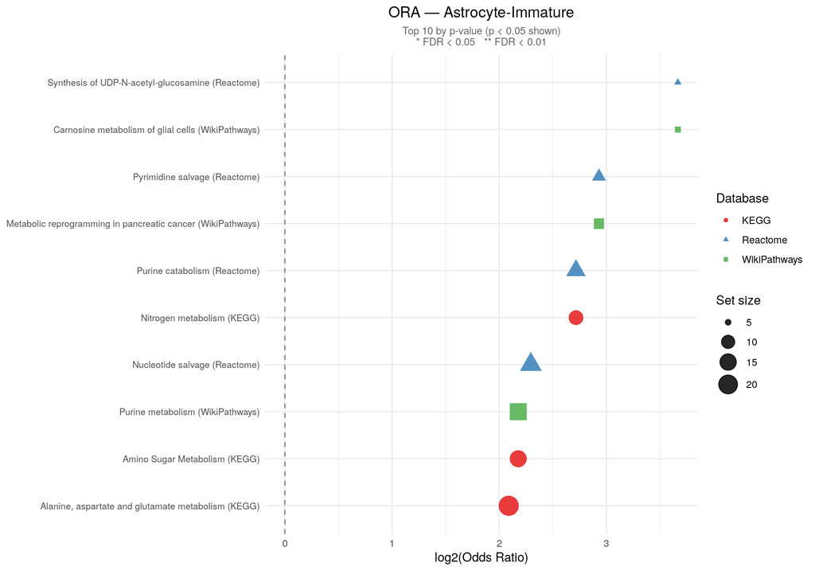

```
## No nominal hits for: EN-L6-IT
```

```
## Saved: ora_ct_EN_L6b.png  +  svg/ora_ct_EN_L6b.svg
```

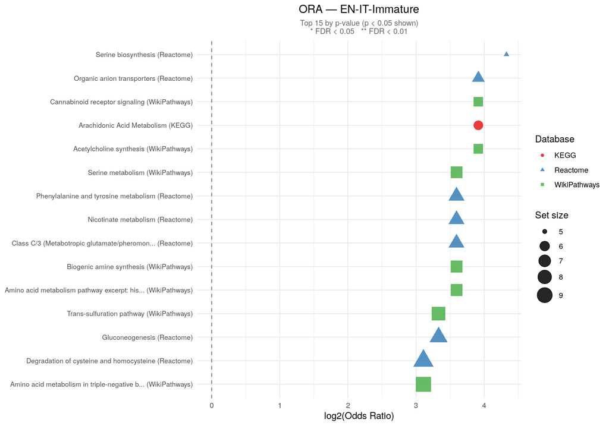

```
## Saved: ora_ct_EN_Newborn.png  +  svg/ora_ct_EN_Newborn.svg
```

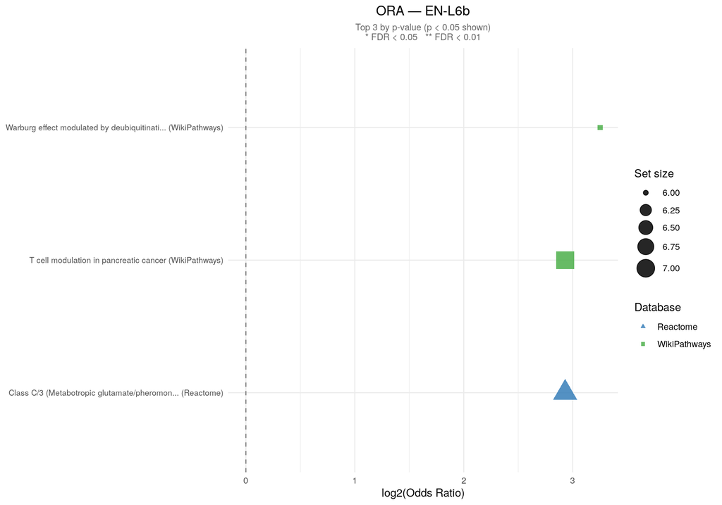

```
## Saved: ora_ct_EN_Non_IT_Immature.png  +  svg/ora_ct_EN_Non_IT_Immature.svg
```

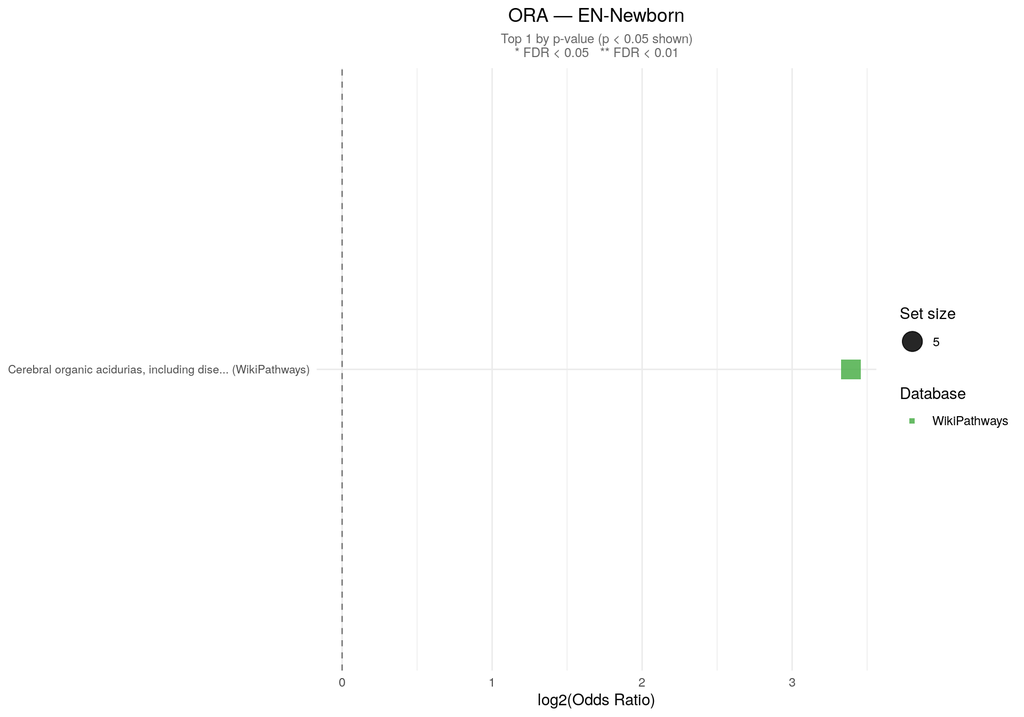

```
## Saved: ora_ct_IN_CGE_Immature.png  +  svg/ora_ct_IN_CGE_Immature.svg
```

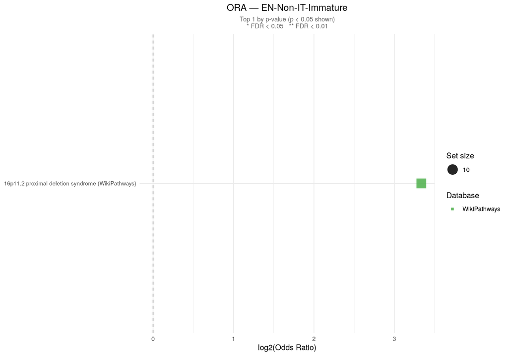

```
## Saved: ora_ct_IN_MGE_Immature.png  +  svg/ora_ct_IN_MGE_Immature.svg
```

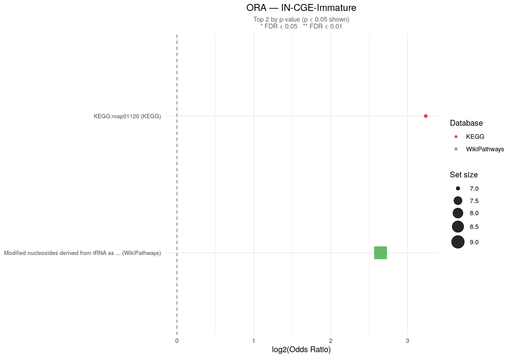

```
## Saved: ora_ct_IN_MGE_SST.png  +  svg/ora_ct_IN_MGE_SST.svg
```

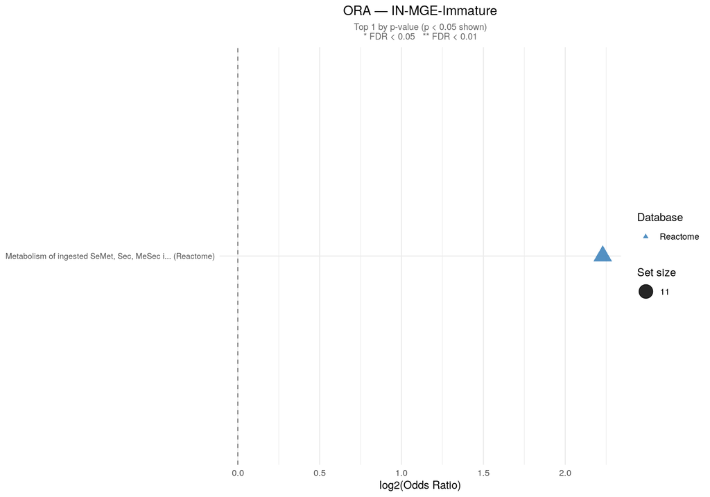

```
## Saved: ora_ct_OPC.png  +  svg/ora_ct_OPC.svg
```

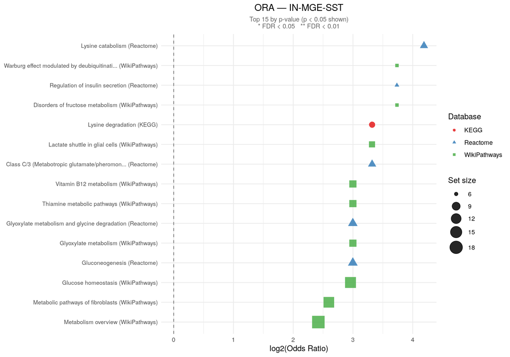

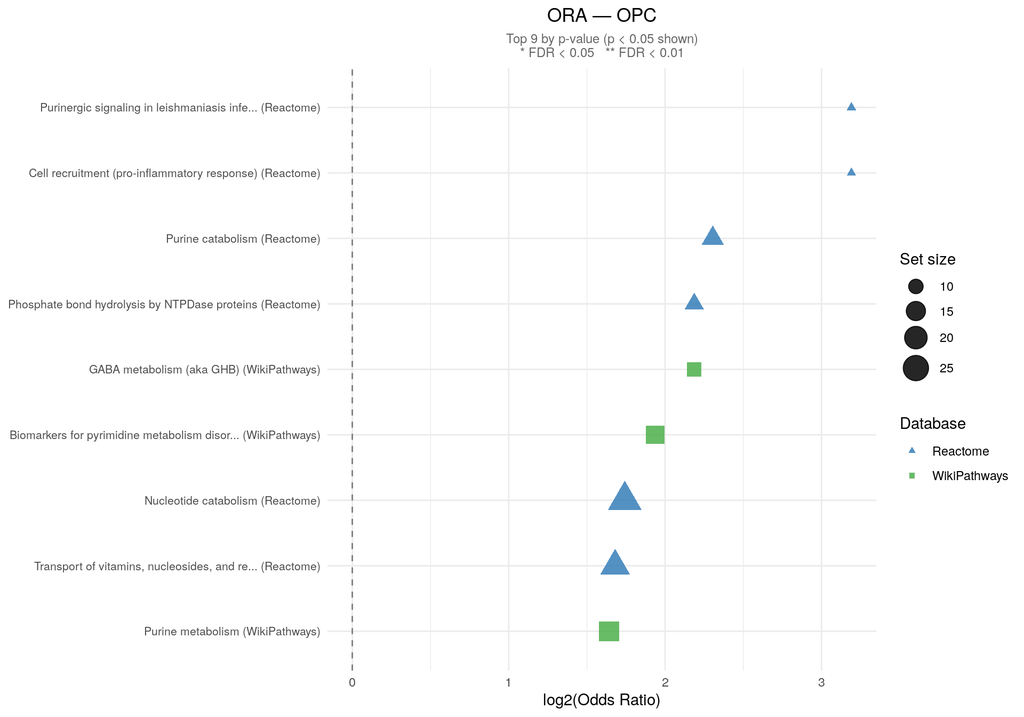

```r
for (ct in names(ora_ct_list)) {
  p <- plot_ora_dotplot(ora_ct_list[[ct]], ct, top_n = 15)
  if (!is.null(p)) {
    ct_safe <- gsub("[^A-Za-z0-9_]", "_", ct)
    save_dual_format(p, out_dir, paste0("ora_ct_", ct_safe))
    print(p)
  }
}
```

## Cell-Type MSEA — Summary Table

```r
ct_msea_summary <- map_dfr(names(msea_ct_list), function(ct) {
  res <- msea_ct_list[[ct]]
  if (is.null(res) || nrow(res) == 0) return(NULL)
  res |>
    left_join(pathway_source_lookup, by = c("pathway" = "pathway_label_src")) |>
    filter(pval < 0.05) |>
    slice_head(n = 3) |>
    mutate(
      cell_type     = ct,
      pathway_short = str_trunc(str_remove(
        pathway, " \\(KEGG\\)$| \\(Reactome\\)$| \\(WikiPathways\\)$| \\(PFOCR\\)$"
      ), 40)
    )
})

if (nrow(ct_msea_summary) > 0) {
  ct_msea_summary |>
    dplyr::select(cell_type, pathway_short, pathway_source,
                  pval, padj, NES, size) |>
    mutate(across(where(is.numeric), ~ signif(.x, 3))) |>
    rename(`Cell type` = cell_type, Pathway = pathway_short,
           Source = pathway_source,
           `p-value` = pval, FDR = padj, `Set size` = size) |>
    kable(caption = "Top 3 MSEA pathways per cell type (p < 0.05)") |>
    kable_styling(bootstrap_options = c("striped", "condensed"),
                  full_width = FALSE, font_size = 10)
}
```

| Cell type | Pathway | Source | p-value | FDR | NES | Set size |
| --- | --- | --- | --- | --- | --- | --- |
| Astrocyte-Immature | Activation of NMDA receptors and post… | Reactome | 0.004600 | 0.2260 | 2.15 | 5 |
| Astrocyte-Immature | Post NMDA receptor activation events | Reactome | 0.004600 | 0.2260 | 2.15 | 5 |
| Astrocyte-Immature | Tryptophan catabolism | Reactome | 0.006200 | 0.2260 | 1.96 | 10 |
| EN-IT-Immature | Acetylcholine synthesis | WikiPathways | 0.001980 | 0.3840 | 2.48 | 6 |
| EN-IT-Immature | Organic anion transporters | Reactome | 0.028800 | 0.9600 | 1.98 | 6 |
| EN-IT-Immature | Nicotinate and nicotinamide metabolism | KEGG | 0.035900 | 0.9600 | 1.91 | 8 |
| EN-L6-IT | Degradation of cysteine and homocysteine | Reactome | 0.003100 | 0.4150 | 2.38 | 9 |
| EN-L6-IT | Sulfur amino acid metabolism | Reactome | 0.005500 | 0.4150 | 2.23 | 14 |
| EN-L6-IT | Organic anion transporters | Reactome | 0.007200 | 0.4150 | 2.27 | 6 |
| EN-L6b | MTHFR deficiency | WikiPathways | 0.022300 | 0.8110 | 2.04 | 5 |
| EN-L6b | Synthesis of wybutosine at G37 of tRN… | Reactome | 0.027300 | 0.8110 | 1.99 | 5 |
| EN-L6b | Orexin receptor pathway | WikiPathways | 0.049200 | 0.8110 | 1.81 | 7 |
| EN-Newborn | Biogenic amine synthesis | WikiPathways | 0.008100 | 0.9650 | 2.23 | 7 |
| EN-Newborn | beta-Alanine metabolism | KEGG | 0.013100 | 0.9650 | 2.11 | 9 |
| EN-Newborn | Biomarkers for urea cycle disorders | WikiPathways | 0.016400 | 0.9650 | 2.04 | 10 |
| EN-Non-IT-Immature | Metabolism of ingested SeMet, Sec, Me… | Reactome | 0.010500 | 0.9370 | 1.57 | 11 |
| EN-Non-IT-Immature | Defective SLC6A19 causes Hartnup diso… | Reactome | 0.016700 | 0.9370 | 1.54 | 10 |
| EN-Non-IT-Immature | Pyruvate metabolism | Reactome | 0.021100 | 0.9370 | 1.51 | 10 |
| IN-CGE-Immature | Metabolic disorders of biological oxi… | Reactome | 0.019500 | 0.7350 | 1.94 | 9 |
| IN-CGE-Immature | Metabolism overview | WikiPathways | 0.025400 | 0.7350 | 1.82 | 18 |
| IN-CGE-Immature | KEGG:map01120 | KEGG | 0.034700 | 0.7350 | 1.84 | 7 |
| IN-MGE-Immature | Metabolism of ingested SeMet, Sec, Me… | Reactome | 0.008100 | 0.9950 | 2.12 | 11 |
| IN-MGE-Immature | Selenocompound metabolism | KEGG | 0.010400 | 0.9950 | 2.12 | 7 |
| IN-MGE-Immature | Defective SLC6A19 causes Hartnup diso… | Reactome | 0.030600 | 0.9950 | 1.87 | 10 |
| IN-MGE-SST | Glucose homeostasis | WikiPathways | 0.002700 | 0.3700 | 1.88 | 14 |
| IN-MGE-SST | Lysine catabolism | Reactome | 0.003900 | 0.3700 | 1.97 | 7 |
| IN-MGE-SST | Class C/3 (Metabotropic glutamate/phe… | Reactome | 0.011500 | 0.3700 | 1.82 | 7 |
| IPC-EN | Biogenic amine synthesis | WikiPathways | 0.000948 | 0.0307 | 1.35 | 7 |
| IPC-EN | Lysine degradation | KEGG | 0.000948 | 0.0307 | 1.35 | 7 |
| IPC-EN | Methionine de novo and salvage pathway | WikiPathways | 0.000948 | 0.0307 | 1.25 | 12 |
| OPC | Aspirin ADME | Reactome | 0.001240 | 0.0804 | 1.53 | 7 |
| OPC | Late SARS-CoV-2 Infection Events | Reactome | 0.001240 | 0.0804 | 1.53 | 7 |
| OPC | Translation of Structural Proteins | Reactome | 0.001240 | 0.0804 | 1.53 | 7 |

## Cell-Type MSEA — Dot Plots

```
## Saved: msea_ct_Astrocyte_Immature.png  +  svg/msea_ct_Astrocyte_Immature.svg
```

```
## Saved: msea_ct_EN_IT_Immature.png  +  svg/msea_ct_EN_IT_Immature.svg
```

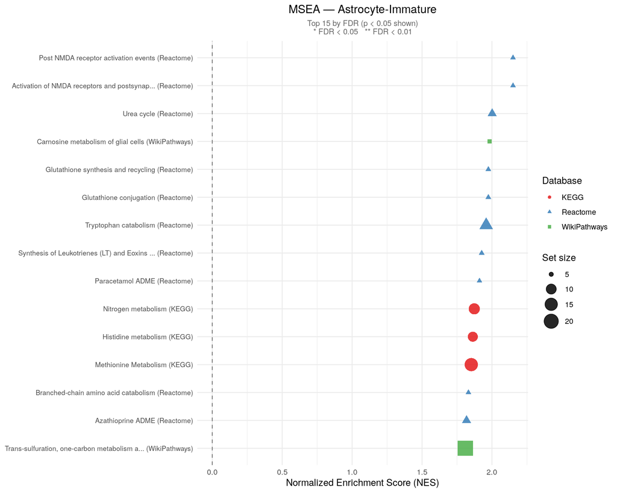

```
## Saved: msea_ct_EN_L6_IT.png  +  svg/msea_ct_EN_L6_IT.svg
```

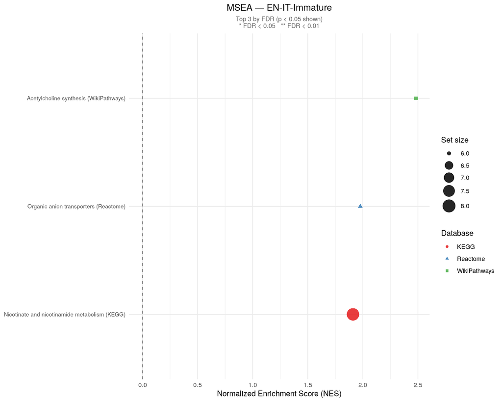

```
## Saved: msea_ct_EN_L6b.png  +  svg/msea_ct_EN_L6b.svg
```

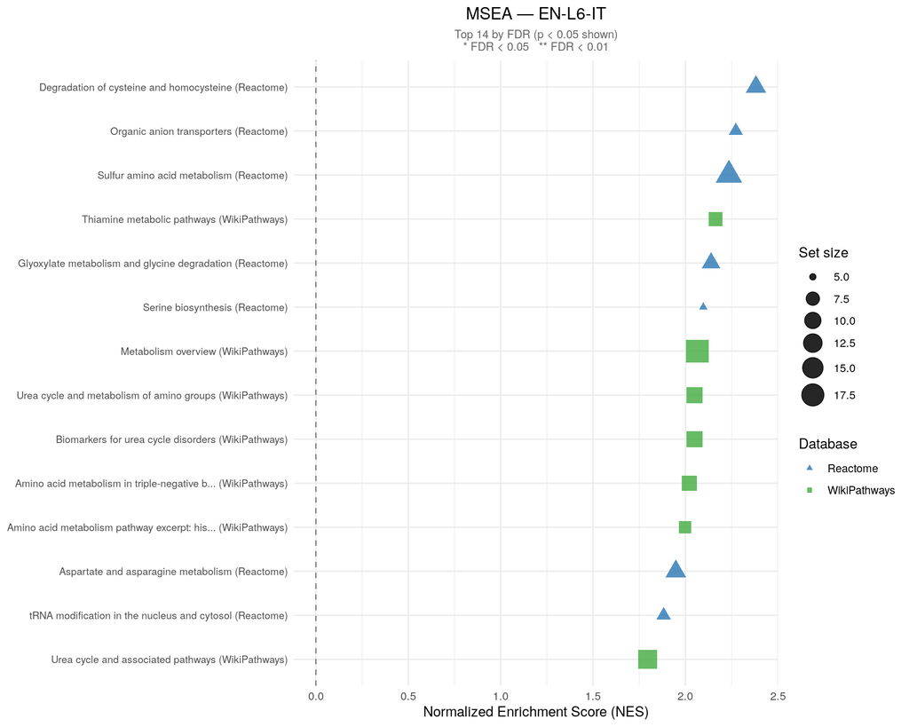

```
## Saved: msea_ct_EN_Newborn.png  +  svg/msea_ct_EN_Newborn.svg
```

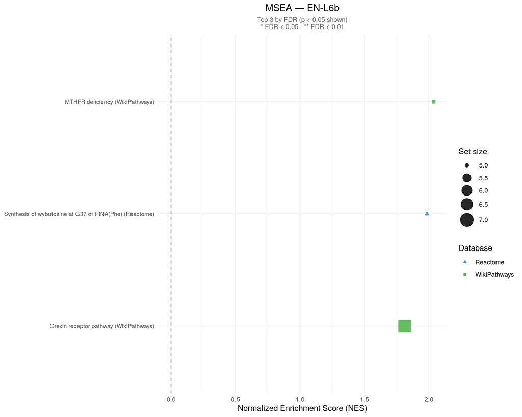

```
## Saved: msea_ct_EN_Non_IT_Immature.png  +  svg/msea_ct_EN_Non_IT_Immature.svg
```

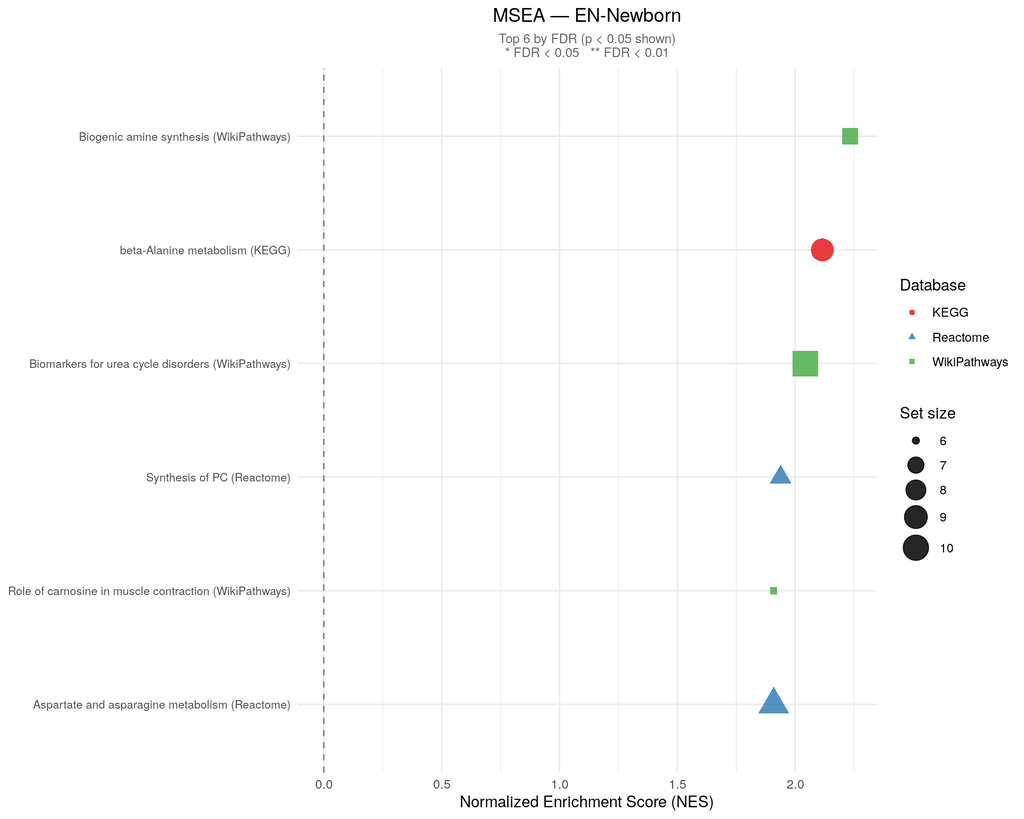

```
## Saved: msea_ct_IN_CGE_Immature.png  +  svg/msea_ct_IN_CGE_Immature.svg
```

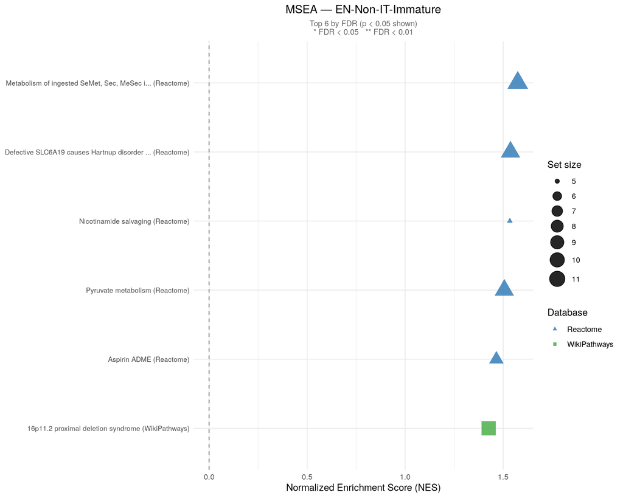

```
## Saved: msea_ct_IN_MGE_Immature.png  +  svg/msea_ct_IN_MGE_Immature.svg
```

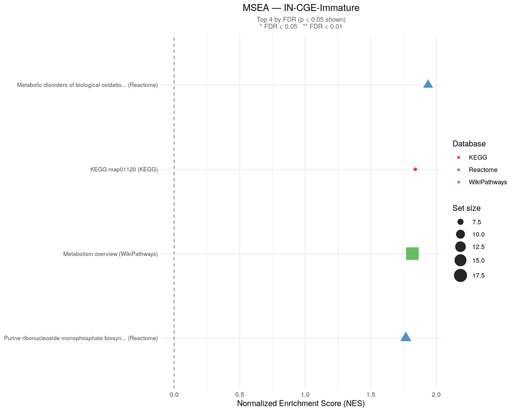

```
## Saved: msea_ct_IN_MGE_SST.png  +  svg/msea_ct_IN_MGE_SST.svg
```

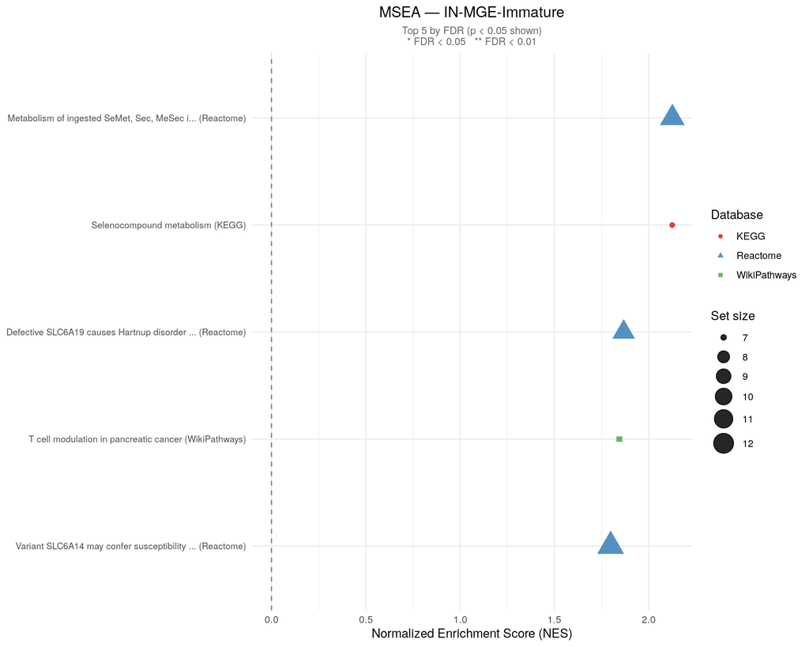

```
## Saved: msea_ct_IPC_EN.png  +  svg/msea_ct_IPC_EN.svg
```

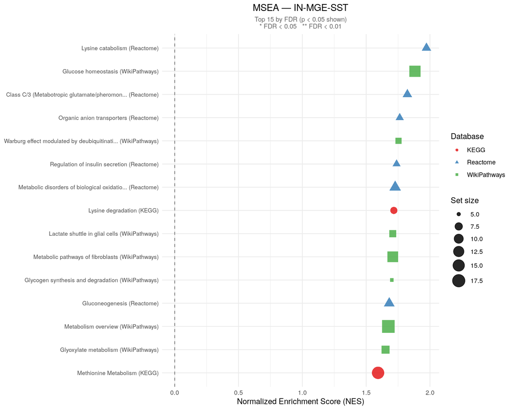

```
## Saved: msea_ct_OPC.png  +  svg/msea_ct_OPC.svg
```

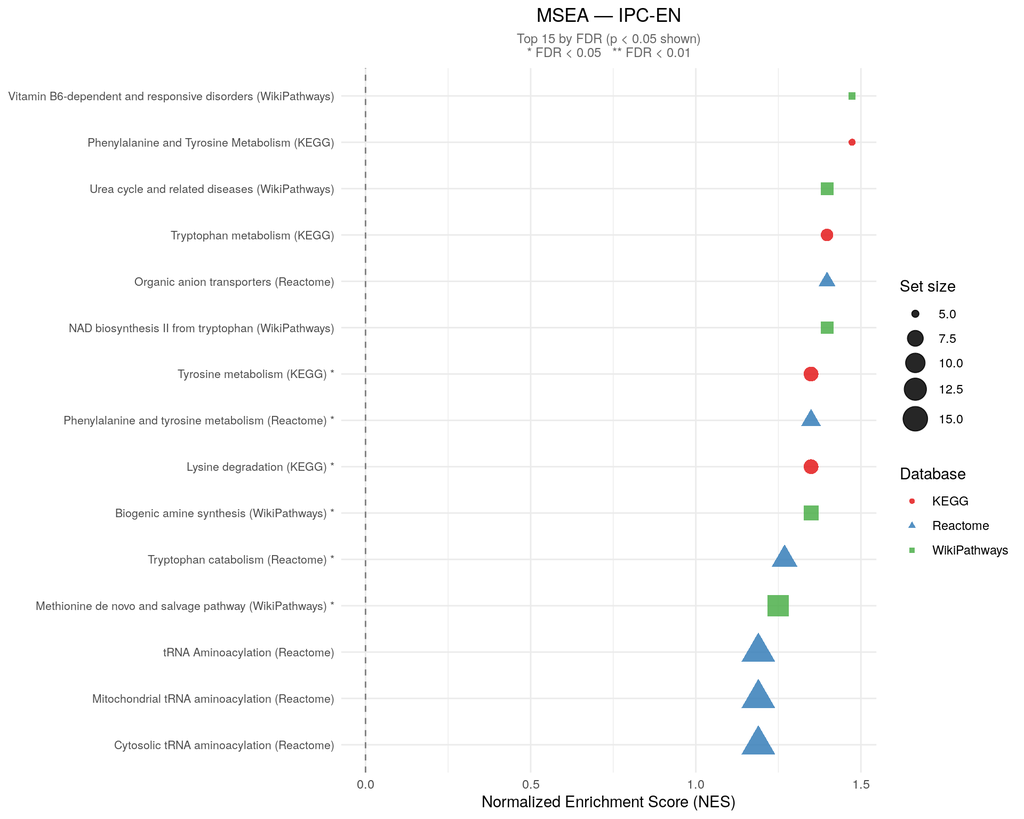

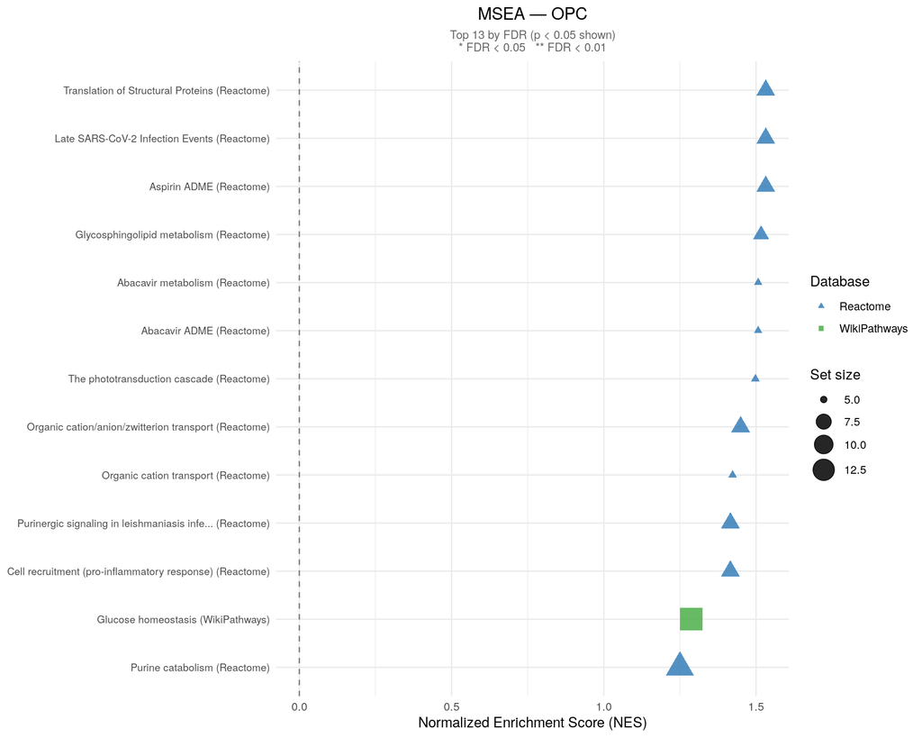

```r
for (ct in names(msea_ct_list)) {
  p <- plot_msea_dotplot(msea_ct_list[[ct]], pathway_source_lookup, ct, top_n = 15)
  if (!is.null(p)) {
    ct_safe <- gsub("[^A-Za-z0-9_]", "_", ct)
    save_dual_format(p, out_dir, paste0("msea_ct_", ct_safe))
    print(p)
  }
}
```

# 3. Glia vs. Neurons

## Define Groups

```r
glia_hits   <- hits |> filter(cell_type %in% GLIAL_TYPES)    |> distinct(Name) |> pull(Name)
neuron_hits <- hits |> filter(cell_type %in% NEURONAL_TYPES) |> distinct(Name) |> pull(Name)

glia_only   <- setdiff(glia_hits,   neuron_hits)
neuron_only <- setdiff(neuron_hits, glia_hits)
shared_both <- intersect(glia_hits, neuron_hits)

cat(sprintf(
  "Glia hits: %d | Neuron hits: %d\nGlia-only: %d | Neuron-only: %d | Shared: %d\n",
  length(glia_hits), length(neuron_hits),
  length(glia_only), length(neuron_only), length(shared_both)
))
```

```
## Glia hits: 92 | Neuron hits: 160
## Glia-only: 61 | Neuron-only: 129 | Shared: 31
```

```r
# Warn about any cell type names that didn't match
unmatched_glia   <- setdiff(GLIAL_TYPES,    unique(hits$cell_type))
unmatched_neuron <- setdiff(NEURONAL_TYPES, unique(hits$cell_type))
if (length(unmatched_glia)   > 0)
  warning("GLIAL_TYPES not in hits: ",    paste(unmatched_glia,   collapse = ", "))
if (length(unmatched_neuron) > 0)
  warning("NEURONAL_TYPES not in hits: ", paste(unmatched_neuron, collapse = ", "))
```

## Metabolite Overlap

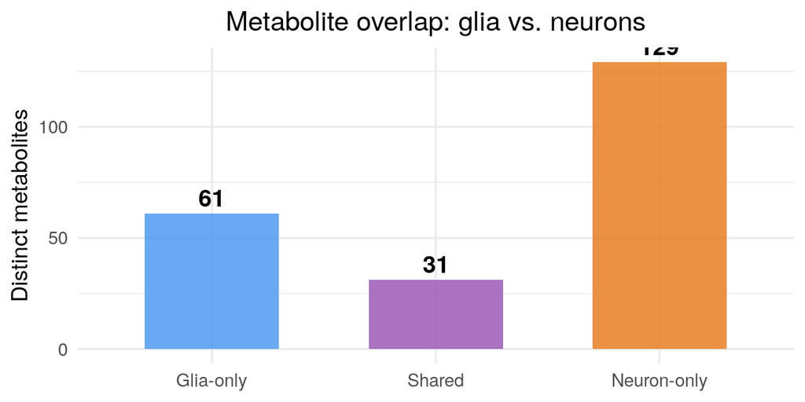

```r
tibble(
  group = factor(c("Glia-only", "Shared", "Neuron-only"),
                 levels = c("Glia-only", "Shared", "Neuron-only")),
  n     = c(length(glia_only), length(shared_both), length(neuron_only))
) |>
  ggplot(aes(x = group, y = n, fill = group)) +
  geom_col(alpha = 0.85, width = 0.6) +
  geom_text(aes(label = n), vjust = -0.4, size = 4.5, fontface = "bold") +
  scale_fill_manual(values = c(
    "Glia-only"   = "#4E9AF1",
    "Shared"      = "#9B59B6",
    "Neuron-only" = "#E67E22"
  )) +
  theme_minimal(base_size = 12) +
  labs(x = NULL, y = "Distinct metabolites",
       title = "Metabolite overlap: glia vs. neurons") +
  theme(legend.position = "none", plot.title = element_text(hjust = 0.5))
```

## ORA — Glia and Neurons

```r
# Four foregrounds: union hits per class, and class-exclusive subsets
ora_glia        <- run_ora(glia_hits,   background_all, pathway_list, pathway_source_lookup, "Glia (union)")
```

```
##
## === Glia (union) ===
## Foreground: 92 | Background: 513
## Pathways with ≥1 hit: 157 | p < 0.05: 11 | FDR < 0.05: 0
```

```r
ora_neuron      <- run_ora(neuron_hits, background_all, pathway_list, pathway_source_lookup, "Neurons (union)")
```

```
##
## === Neurons (union) ===
## Foreground: 160 | Background: 513
## Pathways with ≥1 hit: 184 | p < 0.05: 9 | FDR < 0.05: 0
```

```r
ora_glia_only   <- run_ora(glia_only,   background_all, pathway_list, pathway_source_lookup, "Glia-exclusive")
```

```
##
## === Glia-exclusive ===
## Foreground: 61 | Background: 513
## Pathways with ≥1 hit: 142 | p < 0.05: 13 | FDR < 0.05: 4
```

```r
ora_neuron_only <- run_ora(neuron_only, background_all, pathway_list, pathway_source_lookup, "Neuron-exclusive")
```

```
##
## === Neuron-exclusive ===
## Foreground: 129 | Background: 513
## Pathways with ≥1 hit: 175 | p < 0.05: 13 | FDR < 0.05: 0
```

## MSEA — Glia and Neurons

Rankings collapse across cell types within each group (min P across glial/neuronal cell types per metabolite).

```r
glia_ranking <- ranking_ct_raw |>
  filter(cell_type %in% GLIAL_TYPES) |>
  group_by(Compound.ID, Name) |>
  summarise(min_P = min(min_P, na.rm = TRUE), .groups = "drop")

neuron_ranking <- ranking_ct_raw |>
  filter(cell_type %in% NEURONAL_TYPES) |>
  group_by(Compound.ID, Name) |>
  summarise(min_P = min(min_P, na.rm = TRUE), .groups = "drop")

msea_glia   <- run_msea_metab(glia_ranking,   background_all, pathway_list, "Glia")
```

```
##
## === Glia ===
## Metabolites in ranked list: 513
## Pathway sets after intersection: 194
## Pathways tested: 194 | p < 0.05: 27 | FDR < 0.05: 0
```

```r
msea_neuron <- run_msea_metab(neuron_ranking, background_all, pathway_list, "Neurons")
```

```
##
## === Neurons ===
## Metabolites in ranked list: 513
## Pathway sets after intersection: 194
## Pathways tested: 194 | p < 0.05: 13 | FDR < 0.05: 0
```

## Results — ORA Glia (Union)

```r
display_results_table(ora_glia, "ORA: Glia (union) — top 20", type = "ora")
```

```
## <table class="table table-striped table-condensed" style="font-size: 11px; width: auto !important; margin-left: auto; margin-right: auto;">
## <caption style="font-size: initial !important;">ORA: Glia (union) — top 20</caption>
##  <thead>
##   <tr>
##    <th style="text-align:left;"> Pathway </th>
##    <th style="text-align:left;"> Source </th>
##    <th style="text-align:right;"> Hits </th>
##    <th style="text-align:right;"> Set size </th>
##    <th style="text-align:right;"> OR </th>
##    <th style="text-align:right;"> p-value </th>
##    <th style="text-align:right;"> FDR </th>
##    <th style="text-align:left;"> Hit metabolites </th>
##   </tr>
##  </thead>
## <tbody>
##   <tr>
##    <td style="text-align:left;"> Purine catabolism (Reactome) </td>
##    <td style="text-align:left;"> Reactome </td>
##    <td style="text-align:right;"> 7 </td>
##    <td style="text-align:right;"> 12 </td>
##    <td style="text-align:right;"> 6.81 </td>
##    <td style="text-align:right;"> 0.00176 </td>
##    <td style="text-align:right;"> 0.103 </td>
##    <td style="text-align:left;"> D-Ribose 5-Phosphate;5'-Xanthylic Acid;Guanine;2'-Deoxyad... </td>
##   </tr>
##   <tr>
##    <td style="text-align:left;"> Transport of vitamins, nucleosides, and related molecules (Reactome) </td>
##    <td style="text-align:left;"> Reactome </td>
##    <td style="text-align:right;"> 9 </td>
##    <td style="text-align:right;"> 19 </td>
##    <td style="text-align:right;"> 4.44 </td>
##    <td style="text-align:right;"> 0.00256 </td>
##    <td style="text-align:right;"> 0.103 </td>
##    <td style="text-align:left;"> Cytosine;Guanine;2'-Deoxyadenosine;Adenosine 5'-Diphospha... </td>
##   </tr>
##   <tr>
##    <td style="text-align:left;"> Cell recruitment (pro-inflammatory response) (Reactome) </td>
##    <td style="text-align:left;"> Reactome </td>
##    <td style="text-align:right;"> 5 </td>
##    <td style="text-align:right;"> 7 </td>
```

[output cut: 162 more lines]

```
##    <td style="text-align:right;"> 0.793 </td>
##    <td style="text-align:left;"> D-Ribose 5-Phosphate;D-Fructose 1,6-Bisphosphate;N-Acetyl... </td>
##   </tr>
##   <tr>
##    <td style="text-align:left;"> Organic cation/anion/zwitterion transport (Reactome) </td>
##    <td style="text-align:left;"> Reactome </td>
##    <td style="text-align:right;"> 3 </td>
##    <td style="text-align:right;"> 7 </td>
##    <td style="text-align:right;"> 3.50 </td>
##    <td style="text-align:right;"> 0.11300 </td>
##    <td style="text-align:right;"> 0.793 </td>
##    <td style="text-align:left;"> Creatinine;Dl-Carnitine;Uric Acid </td>
##   </tr>
## </tbody>
## </table>
```

```
## Saved: ora_glia.png  +  svg/ora_glia.svg
```

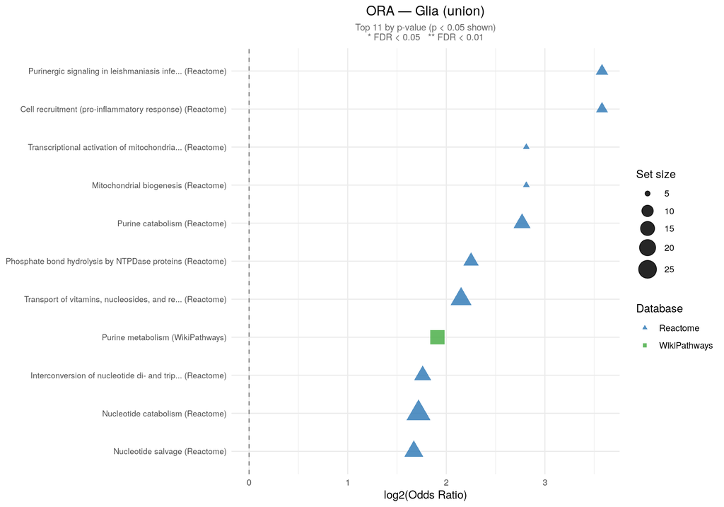

```r
p <- plot_ora_dotplot(ora_glia, "Glia (union)")
if (!is.null(p)) { save_dual_format(p, out_dir, "ora_glia"); print(p) }
```

## Results — ORA Neurons (Union)

```r
display_results_table(ora_neuron, "ORA: Neurons (union) — top 20", type = "ora")
```

```
## <table class="table table-striped table-condensed" style="font-size: 11px; width: auto !important; margin-left: auto; margin-right: auto;">
## <caption style="font-size: initial !important;">ORA: Neurons (union) — top 20</caption>
##  <thead>
##   <tr>
##    <th style="text-align:left;"> Pathway </th>
##    <th style="text-align:left;"> Source </th>
##    <th style="text-align:right;"> Hits </th>
##    <th style="text-align:right;"> Set size </th>
##    <th style="text-align:right;"> OR </th>
##    <th style="text-align:right;"> p-value </th>
##    <th style="text-align:right;"> FDR </th>
##    <th style="text-align:left;"> Hit metabolites </th>
##   </tr>
##  </thead>
## <tbody>
##   <tr>
##    <td style="text-align:left;"> Cerebral organic acidurias, including diseases (WikiPathways) </td>
##    <td style="text-align:left;"> WikiPathways </td>
##    <td style="text-align:right;"> 5 </td>
##    <td style="text-align:right;"> 5 </td>
##    <td style="text-align:right;"> Inf </td>
##    <td style="text-align:right;"> 0.00283 </td>
##    <td style="text-align:right;"> 0.411 </td>
##    <td style="text-align:left;"> N-Acetyl-L-Aspartic Acid;2-Oxoadipic Acid;L-2-Aminoadipic... </td>
##   </tr>
##   <tr>
##    <td style="text-align:left;"> Lysine catabolism (Reactome) </td>
##    <td style="text-align:left;"> Reactome </td>
##    <td style="text-align:right;"> 6 </td>
##    <td style="text-align:right;"> 7 </td>
##    <td style="text-align:right;"> 13.65 </td>
##    <td style="text-align:right;"> 0.00446 </td>
##    <td style="text-align:right;"> 0.411 </td>
##    <td style="text-align:left;"> L-Lysine;2-Oxoadipic Acid;L-Glutamic Acid;L-2-Aminoadipic... </td>
##   </tr>
##   <tr>
##    <td style="text-align:left;"> Glyoxylate metabolism and glycine degradation (Reactome) </td>
##    <td style="text-align:left;"> Reactome </td>
##    <td style="text-align:right;"> 6 </td>
##    <td style="text-align:right;"> 8 </td>
```

[output cut: 162 more lines]

```
##    <td style="text-align:right;"> 0.767 </td>
##    <td style="text-align:left;"> Dl-Alanine;L-Lysine;L-Glutamic Acid;Leucine;Asparagine;Tr... </td>
##   </tr>
##   <tr>
##    <td style="text-align:left;"> Mitochondrial tRNA aminoacylation (Reactome) </td>
##    <td style="text-align:left;"> Reactome </td>
##    <td style="text-align:right;"> 8 </td>
##    <td style="text-align:right;"> 16 </td>
##    <td style="text-align:right;"> 2.27 </td>
##    <td style="text-align:right;"> 0.08750 </td>
##    <td style="text-align:right;"> 0.767 </td>
##    <td style="text-align:left;"> Dl-Alanine;L-Lysine;L-Glutamic Acid;Leucine;Asparagine;Tr... </td>
##   </tr>
## </tbody>
## </table>
```

```
## Saved: ora_neurons.png  +  svg/ora_neurons.svg
```

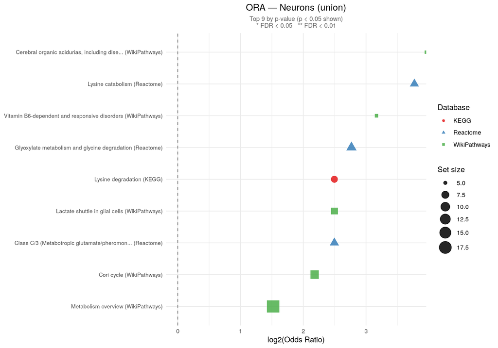

```r
p <- plot_ora_dotplot(ora_neuron, "Neurons (union)")
if (!is.null(p)) { save_dual_format(p, out_dir, "ora_neurons"); print(p) }
```

## Results — ORA Glia-Exclusive

```r
display_results_table(ora_glia_only, "ORA: Glia-exclusive metabolites — top 20", type = "ora")
```

```
## <table class="table table-striped table-condensed" style="font-size: 11px; width: auto !important; margin-left: auto; margin-right: auto;">
## <caption style="font-size: initial !important;">ORA: Glia-exclusive metabolites — top 20</caption>
##  <thead>
##   <tr>
##    <th style="text-align:left;"> Pathway </th>
##    <th style="text-align:left;"> Source </th>
##    <th style="text-align:right;"> Hits </th>
##    <th style="text-align:right;"> Set size </th>
##    <th style="text-align:right;"> OR </th>
##    <th style="text-align:right;"> p-value </th>
##    <th style="text-align:right;"> FDR </th>
##    <th style="text-align:left;"> Hit metabolites </th>
##   </tr>
##  </thead>
## <tbody>
##   <tr>
##    <td style="text-align:left;"> Cell recruitment (pro-inflammatory response) (Reactome) </td>
##    <td style="text-align:left;"> Reactome </td>
##    <td style="text-align:right;"> 5 </td>
##    <td style="text-align:right;"> 7 </td>
##    <td style="text-align:right;"> 19.85 </td>
##    <td style="text-align:right;"> 0.000355 </td>
##    <td style="text-align:right;"> 0.0252 </td>
##    <td style="text-align:left;"> Uridine 5'-Diphosphate;Cytidine 5'-Diphosphate;Adenosine ... </td>
##   </tr>
##   <tr>
##    <td style="text-align:left;"> Purinergic signaling in leishmaniasis infection (Reactome) </td>
##    <td style="text-align:left;"> Reactome </td>
##    <td style="text-align:right;"> 5 </td>
##    <td style="text-align:right;"> 7 </td>
##    <td style="text-align:right;"> 19.85 </td>
##    <td style="text-align:right;"> 0.000355 </td>
##    <td style="text-align:right;"> 0.0252 </td>
##    <td style="text-align:left;"> Uridine 5'-Diphosphate;Cytidine 5'-Diphosphate;Adenosine ... </td>
##   </tr>
##   <tr>
##    <td style="text-align:left;"> Purine catabolism (Reactome) </td>
##    <td style="text-align:left;"> Reactome </td>
##    <td style="text-align:right;"> 6 </td>
##    <td style="text-align:right;"> 12 </td>
```

[output cut: 162 more lines]

```
##    <td style="text-align:right;"> 0.5380 </td>
##    <td style="text-align:left;"> Uridine 5'-Diphosphate;Adenosine 5'-Diphosphate </td>
##   </tr>
##   <tr>
##    <td style="text-align:left;"> Abacavir metabolism (Reactome) </td>
##    <td style="text-align:left;"> Reactome </td>
##    <td style="text-align:right;"> 2 </td>
##    <td style="text-align:right;"> 5 </td>
##    <td style="text-align:right;"> 5.05 </td>
##    <td style="text-align:right;"> 0.110000 </td>
##    <td style="text-align:right;"> 0.5380 </td>
##    <td style="text-align:left;"> Uridine 5'-Diphosphate;Adenosine 5'-Diphosphate </td>
##   </tr>
## </tbody>
## </table>
```

```
## Saved: ora_glia_only.png  +  svg/ora_glia_only.svg
```

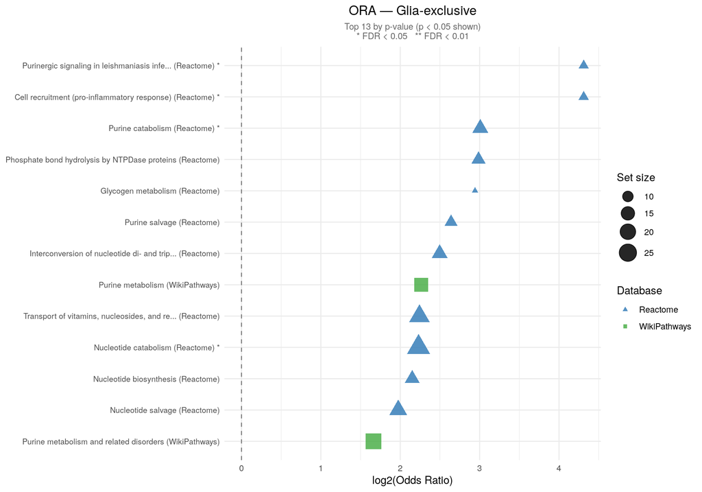

```r
p <- plot_ora_dotplot(ora_glia_only, "Glia-exclusive")
if (!is.null(p)) { save_dual_format(p, out_dir, "ora_glia_only"); print(p) }
```

## Results — ORA Neuron-Exclusive

```r
display_results_table(ora_neuron_only, "ORA: Neuron-exclusive metabolites — top 20", type = "ora")
```

```
## <table class="table table-striped table-condensed" style="font-size: 11px; width: auto !important; margin-left: auto; margin-right: auto;">
## <caption style="font-size: initial !important;">ORA: Neuron-exclusive metabolites — top 20</caption>
##  <thead>
##   <tr>
##    <th style="text-align:left;"> Pathway </th>
##    <th style="text-align:left;"> Source </th>
##    <th style="text-align:right;"> Hits </th>
##    <th style="text-align:right;"> Set size </th>
##    <th style="text-align:right;"> OR </th>
##    <th style="text-align:right;"> p-value </th>
##    <th style="text-align:right;"> FDR </th>
##    <th style="text-align:left;"> Hit metabolites </th>
##   </tr>
##  </thead>
## <tbody>
##   <tr>
##    <td style="text-align:left;"> Cori cycle (WikiPathways) </td>
##    <td style="text-align:left;"> WikiPathways </td>
##    <td style="text-align:right;"> 6 </td>
##    <td style="text-align:right;"> 9 </td>
##    <td style="text-align:right;"> 6.17 </td>
##    <td style="text-align:right;"> 0.00969 </td>
##    <td style="text-align:right;"> 0.472 </td>
##    <td style="text-align:left;"> Pyruvic Acid;Dl-Alanine;Dl-Lactic Acid;Dihydroxyacetone P... </td>
##   </tr>
##   <tr>
##    <td style="text-align:left;"> Lactate shuttle in glial cells (WikiPathways) </td>
##    <td style="text-align:left;"> WikiPathways </td>
##    <td style="text-align:right;"> 5 </td>
##    <td style="text-align:right;"> 7 </td>
##    <td style="text-align:right;"> 7.66 </td>
##    <td style="text-align:right;"> 0.01270 </td>
##    <td style="text-align:right;"> 0.472 </td>
##    <td style="text-align:left;"> Pyruvic Acid;Dl-Lactic Acid;D-Glucose 6-Phosphate;Udp-Β-D... </td>
##   </tr>
##   <tr>
##    <td style="text-align:left;"> Lysine catabolism (Reactome) </td>
##    <td style="text-align:left;"> Reactome </td>
##    <td style="text-align:right;"> 5 </td>
##    <td style="text-align:right;"> 7 </td>
```

[output cut: 162 more lines]

```
##    <td style="text-align:right;"> 0.515 </td>
##    <td style="text-align:left;"> Pyruvic Acid;Dl-Alanine;L-Glutamic Acid;L-Aspartic Acid </td>
##   </tr>
##   <tr>
##    <td style="text-align:left;"> Sensory perception of sweet, bitter, and umami (glutamate) taste (Reactome) </td>
##    <td style="text-align:left;"> Reactome </td>
##    <td style="text-align:right;"> 4 </td>
##    <td style="text-align:right;"> 7 </td>
##    <td style="text-align:right;"> 4.05 </td>
##    <td style="text-align:right;"> 0.07050 </td>
##    <td style="text-align:right;"> 0.515 </td>
##    <td style="text-align:left;"> D-Glucose;L-Glutamic Acid;Guanosine 5'-Diphosphate (Gdp);... </td>
##   </tr>
## </tbody>
## </table>
```

```
## Saved: ora_neuron_only.png  +  svg/ora_neuron_only.svg
```

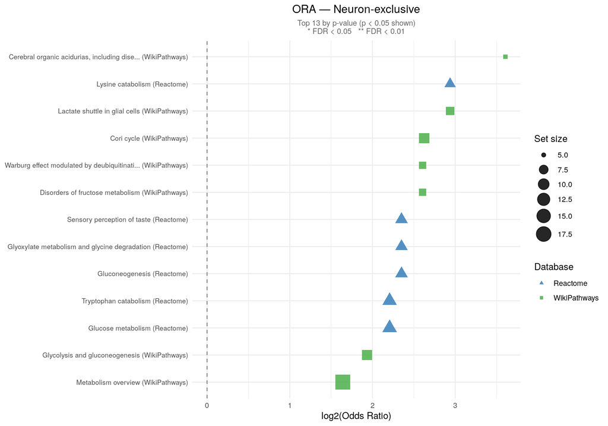

```r
p <- plot_ora_dotplot(ora_neuron_only, "Neuron-exclusive")
if (!is.null(p)) { save_dual_format(p, out_dir, "ora_neuron_only"); print(p) }
```

## Results — MSEA Glia

```r
display_results_table(msea_glia, "MSEA: Glia — top 20", type = "msea")
```

```
## <table class="table table-striped table-condensed" style="font-size: 11px; width: auto !important; margin-left: auto; margin-right: auto;">
## <caption style="font-size: initial !important;">MSEA: Glia — top 20</caption>
##  <thead>
##   <tr>
##    <th style="text-align:left;"> Pathway </th>
##    <th style="text-align:left;"> Source </th>
##    <th style="text-align:right;"> p-value </th>
##    <th style="text-align:right;"> FDR </th>
##    <th style="text-align:right;"> NES </th>
##    <th style="text-align:right;"> Set size </th>
##    <th style="text-align:left;"> Leading edge (top 5) </th>
##   </tr>
##  </thead>
## <tbody>
##   <tr>
##    <td style="text-align:left;"> Cell recruitment (pro-inflammatory response) (Reactome) </td>
##    <td style="text-align:left;"> Reactome </td>
##    <td style="text-align:right;"> 0.00115 </td>
##    <td style="text-align:right;"> 0.110 </td>
##    <td style="text-align:right;"> 2.247 </td>
##    <td style="text-align:right;"> 7 </td>
##    <td style="text-align:left;"> Uridine 5'-Diphosphate, Guanosine-5'-Monophosphate, Adenosine 5'-Diphosphate, Cytidine 5'-Diphosphate, Uridine Monophosphate </td>
##   </tr>
##   <tr>
##    <td style="text-align:left;"> Purinergic signaling in leishmaniasis infection (Reactome) </td>
##    <td style="text-align:left;"> Reactome </td>
##    <td style="text-align:right;"> 0.00115 </td>
##    <td style="text-align:right;"> 0.110 </td>
##    <td style="text-align:right;"> 2.247 </td>
##    <td style="text-align:right;"> 7 </td>
##    <td style="text-align:left;"> Uridine 5'-Diphosphate, Guanosine-5'-Monophosphate, Adenosine 5'-Diphosphate, Cytidine 5'-Diphosphate, Uridine Monophosphate </td>
##   </tr>
##   <tr>
##    <td style="text-align:left;"> Purine catabolism (Reactome) </td>
##    <td style="text-align:left;"> Reactome </td>
##    <td style="text-align:right;"> 0.00170 </td>
##    <td style="text-align:right;"> 0.110 </td>
##    <td style="text-align:right;"> 2.060 </td>
##    <td style="text-align:right;"> 12 </td>
##    <td style="text-align:left;"> 5'-Xanthylic Acid, Guanosine-5'-Monophosphate, 2'-Deoxyadenosine, Uric Acid, Adenosine 5'-Diphosphate </td>
```

[output cut: 141 more lines]

```
##    <td style="text-align:right;"> 1.646 </td>
##    <td style="text-align:right;"> 8 </td>
##    <td style="text-align:left;"> Glycolic Acid, Sarcosine, L-Aspartic Acid, L-Hydroxyproline, Glycine </td>
##   </tr>
##   <tr>
##    <td style="text-align:left;"> Glutathione conjugation (Reactome) </td>
##    <td style="text-align:left;"> Reactome </td>
##    <td style="text-align:right;"> 0.04710 </td>
##    <td style="text-align:right;"> 0.340 </td>
##    <td style="text-align:right;"> 1.690 </td>
##    <td style="text-align:right;"> 5 </td>
##    <td style="text-align:left;"> Adenosine 5'-Diphosphate, L-Glutamic Acid, Glycine, L-Pyroglutamic Acid, L-Glutathione (Reduced) </td>
##   </tr>
## </tbody>
## </table>
```

```
## Saved: msea_glia.png  +  svg/msea_glia.svg
```

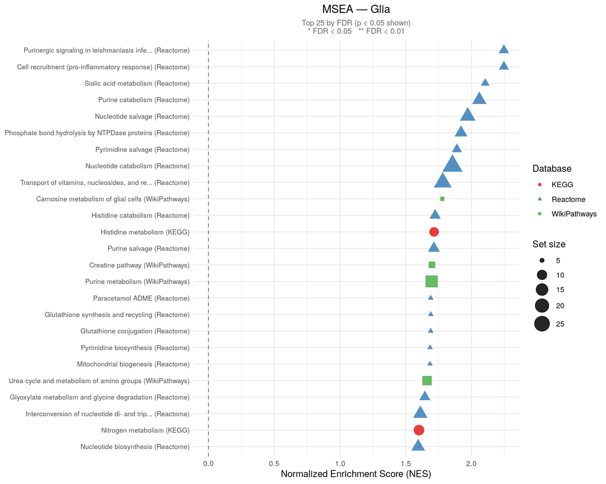

```r
p <- plot_msea_dotplot(msea_glia, pathway_source_lookup, "Glia")
if (!is.null(p)) { save_dual_format(p, out_dir, "msea_glia"); print(p) }
```

## Results — MSEA Neurons

```r
display_results_table(msea_neuron, "MSEA: Neurons — top 20", type = "msea")
```

```
## <table class="table table-striped table-condensed" style="font-size: 11px; width: auto !important; margin-left: auto; margin-right: auto;">
## <caption style="font-size: initial !important;">MSEA: Neurons — top 20</caption>
##  <thead>
##   <tr>
##    <th style="text-align:left;"> Pathway </th>
##    <th style="text-align:left;"> Source </th>
##    <th style="text-align:right;"> p-value </th>
##    <th style="text-align:right;"> FDR </th>
##    <th style="text-align:right;"> NES </th>
##    <th style="text-align:right;"> Set size </th>
##    <th style="text-align:left;"> Leading edge (top 5) </th>
##   </tr>
##  </thead>
## <tbody>
##   <tr>
##    <td style="text-align:left;"> Lysine catabolism (Reactome) </td>
##    <td style="text-align:left;"> Reactome </td>
##    <td style="text-align:right;"> 0.000358 </td>
##    <td style="text-align:right;"> 0.0694 </td>
##    <td style="text-align:right;"> 2.668 </td>
##    <td style="text-align:right;"> 7 </td>
##    <td style="text-align:left;"> L-Lysine, 2-Oxoadipic Acid, L-Saccharopine, L-Glutamic Acid, Guanosine 5'-Diphosphate (Gdp) </td>
##   </tr>
##   <tr>
##    <td style="text-align:left;"> Cerebral organic acidurias, including diseases (WikiPathways) </td>
##    <td style="text-align:left;"> WikiPathways </td>
##    <td style="text-align:right;"> 0.002130 </td>
##    <td style="text-align:right;"> 0.2060 </td>
##    <td style="text-align:right;"> 2.619 </td>
##    <td style="text-align:right;"> 5 </td>
##    <td style="text-align:left;"> Tryptophan, 2-Oxoadipic Acid, L-2-Aminoadipic Acid, L-Aspartic Acid, N-Acetyl-L-Aspartic Acid </td>
##   </tr>
##   <tr>
##    <td style="text-align:left;"> Glyoxylate metabolism and glycine degradation (Reactome) </td>
##    <td style="text-align:left;"> Reactome </td>
##    <td style="text-align:right;"> 0.003400 </td>
##    <td style="text-align:right;"> 0.2200 </td>
##    <td style="text-align:right;"> 2.395 </td>
##    <td style="text-align:right;"> 8 </td>
##    <td style="text-align:left;"> Pyruvic Acid, L-Hydroxyproline, Sarcosine, Glycolic Acid, L-Aspartic Acid </td>
```

[output cut: 141 more lines]

```
##    <td style="text-align:right;"> 1.773 </td>
##    <td style="text-align:right;"> 7 </td>
##    <td style="text-align:left;"> Pyruvic Acid, L-Glutamic Acid, L-Aspartic Acid, Dl-Alanine </td>
##   </tr>
##   <tr>
##    <td style="text-align:left;"> Disorders of fructose metabolism (WikiPathways) </td>
##    <td style="text-align:left;"> WikiPathways </td>
##    <td style="text-align:right;"> 0.073400 </td>
##    <td style="text-align:right;"> 0.6710 </td>
##    <td style="text-align:right;"> 1.767 </td>
##    <td style="text-align:right;"> 6 </td>
##    <td style="text-align:left;"> Pyruvic Acid, D-Glucose 6-Phosphate, Dihydroxyacetone Phosphate, Glucose 1-Phosphate </td>
##   </tr>
## </tbody>
## </table>
```

```
## Saved: msea_neurons.png  +  svg/msea_neurons.svg
```

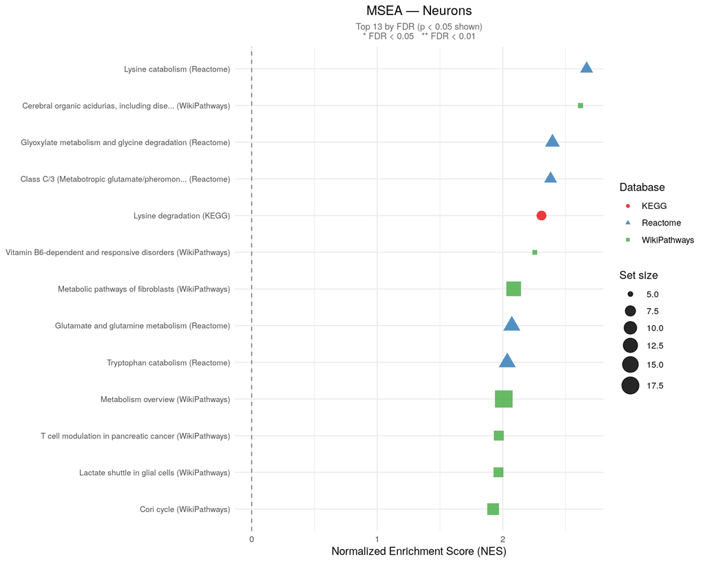

```r
p <- plot_msea_dotplot(msea_neuron, pathway_source_lookup, "Neurons")
if (!is.null(p)) { save_dual_format(p, out_dir, "msea_neurons"); print(p) }
```

## Shared Pathways: Glia vs. Neurons (ORA)

Pathways nominally significant (p < 0.05) in **both** glia and neurons; scatter shows whether each pathway skews glial or neuronal based on log2(OR). Points above the diagonal are stronger in neurons; below, stronger in glia.

```r
if (!is.null(ora_glia) && !is.null(ora_neuron)) {
  shared_pathways <- inner_join(
    ora_glia   |> filter(pval < 0.05) |>
      dplyr::select(pathway, or_glia   = odds_ratio, pval_glia   = pval, padj_glia   = padj),
    ora_neuron |> filter(pval < 0.05) |>
      dplyr::select(pathway, or_neuron = odds_ratio, pval_neuron = pval, padj_neuron = padj),
    by = "pathway"
  ) |>
    left_join(pathway_source_lookup, by = c("pathway" = "pathway_label_src")) |>
    mutate(
      pathway_short  = str_trunc(str_remove(
        pathway, " \\(KEGG\\)$| \\(Reactome\\)$| \\(WikiPathways\\)$| \\(PFOCR\\)$"
      ), 38),
      log2_or_glia   = log2(or_glia),
      log2_or_neuron = log2(or_neuron)
    )

  cat(sprintf(
    "Pathways significant in both glia and neurons (p < 0.05): %d\n",
    nrow(shared_pathways)
  ))

  if (nrow(shared_pathways) > 0) {
    p_overlap <- ggplot(shared_pathways,
                        aes(x = log2_or_glia, y = log2_or_neuron,
                            color = pathway_source, label = pathway_short)) +
      geom_point(alpha = 0.8, size = 3) +
      geom_abline(slope = 1, intercept = 0, linetype = "dashed", color = "grey60") +
      geom_hline(yintercept = 0, linetype = "dotted", color = "grey70") +
      geom_vline(xintercept = 0, linetype = "dotted", color = "grey70") +
      ggrepel::geom_text_repel(size = 3, max.overlaps = 15) +
      scale_color_manual(name = "Database",
        values = c(KEGG = "#E41A1C", Reactome = "#377EB8",
                   WikiPathways = "#4DAF4A", PFOCR = "#FF7F00")) +
      theme_minimal(base_size = 11) +
      labs(x = "log2(OR) in Glia", y = "log2(OR) in Neurons",
           title    = "Shared pathways: Glia vs. Neurons (ORA)",
           subtitle = "Above diagonal = stronger in neurons | Below = stronger in glia") +
      theme(plot.title    = element_text(hjust = 0.5),
            plot.subtitle = element_text(hjust = 0.5, color = "grey40", size = 9))

    save_dual_format(p_overlap, out_dir, "glia_neuron_pathway_overlap")
    print(p_overlap)
  }
}
```

```
## Pathways significant in both glia and neurons (p < 0.05): 0
```

# Save Results

```r
# --- All cell types ---
if (!is.null(ora_all))  write_csv(ora_all,                      file.path(csv_path, "ora_all_celltypes.csv"))
if (!is.null(msea_all)) write_csv(flatten_leading_edge(msea_all), file.path(csv_path, "msea_all_celltypes.csv"))

# --- Cell-type-specific ---
for (ct in names(ora_ct_list)) {
  ct_safe <- gsub("[^A-Za-z0-9_]", "_", ct)
  if (!is.null(ora_ct_list[[ct]]))
    write_csv(ora_ct_list[[ct]], file.path(csv_path, paste0("ora_ct_", ct_safe, ".csv")))
}
for (ct in names(msea_ct_list)) {
  ct_safe <- gsub("[^A-Za-z0-9_]", "_", ct)
  if (!is.null(msea_ct_list[[ct]]))
    write_csv(flatten_leading_edge(msea_ct_list[[ct]]),
              file.path(csv_path, paste0("msea_ct_", ct_safe, ".csv")))
}
if (exists("ct_ora_summary")  && nrow(ct_ora_summary)  > 0)
  write_csv(ct_ora_summary,  file.path(csv_path, "ora_celltype_summary.csv"))
if (exists("ct_msea_summary") && nrow(ct_msea_summary) > 0)
  write_csv(ct_msea_summary, file.path(csv_path, "msea_celltype_summary.csv"))

# --- Glia vs. neurons ---
if (!is.null(ora_glia))        write_csv(ora_glia,                          file.path(csv_path, "ora_glia.csv"))
if (!is.null(ora_neuron))      write_csv(ora_neuron,                        file.path(csv_path, "ora_neuron.csv"))
if (!is.null(ora_glia_only))   write_csv(ora_glia_only,                     file.path(csv_path, "ora_glia_only.csv"))
if (!is.null(ora_neuron_only)) write_csv(ora_neuron_only,                   file.path(csv_path, "ora_neuron_only.csv"))
if (!is.null(msea_glia))       write_csv(flatten_leading_edge(msea_glia),   file.path(csv_path, "msea_glia.csv"))
if (!is.null(msea_neuron))     write_csv(flatten_leading_edge(msea_neuron), file.path(csv_path, "msea_neuron.csv"))

cat("All results saved to:", csv_path, "\n")
```

```
## All results saved to: /scratch/jdlab/sneha/developing-brain-metabolomics/results/gene-metabolite/stability-imputation-log2_na/pathway/csv
```

# AI Assistance Disclosure

Code in this script was developed with assistance from Claude (Anthropic). All AI-generated code was reviewed, validated, and adapted by the author.